# IE 582 Homework 1

# Task 1

The aim of the first task is to understand of the nature of the data that if the number of goals in a match may fit into a distribution which consists the results of the Soccer matches played in the English Premier League. In this part, we have given the data including the following self-explanatory rows:  match_id  epoch  match_status  match_live  match_hometeam_id  match_hometeam_name  match_awayteam_id  match_awayteam_name  match_hometeam_score  match_awayteam_score  match_hometeam_halftime_score  match_awayteam_halftime_score  match_hometeam_extra_score  match_awayteam_extra_score  match_hometeam_penalty_score  match_awayteam_penalty_score  league_id

Given the data, firstly, I have read the data file and remove the empty columns that includes the data of unfinished matches.

```r
matches <- read.csv("matches.csv")
finishedmatchesall <- matches[!is.na(matches$match_hometeam_score), ]
finishedmatches <- finishedmatchesall[finishedmatchesall$league_id =="148",]
nrow(finishedmatches)
```

618

The number of finished matches,as stated above, was 618 and I plotted the histogram of number of goals for home team, away team and the histogram of the score diferences in the matches. The plots are as follows:

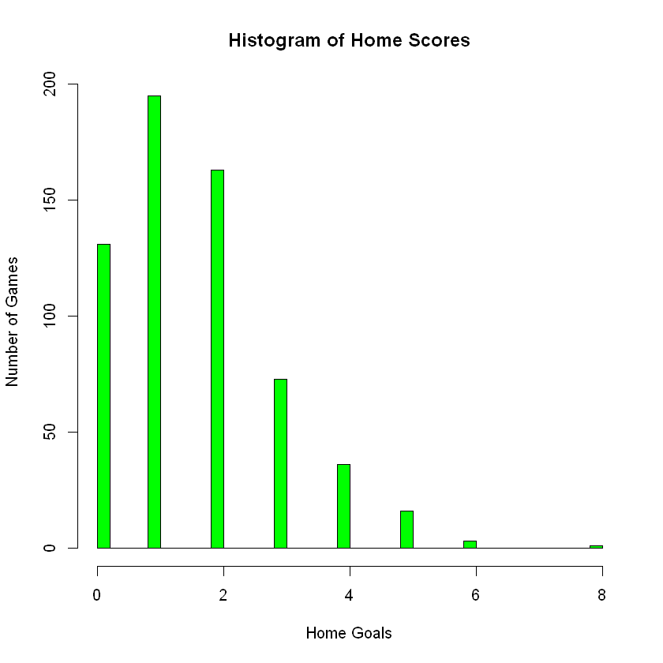

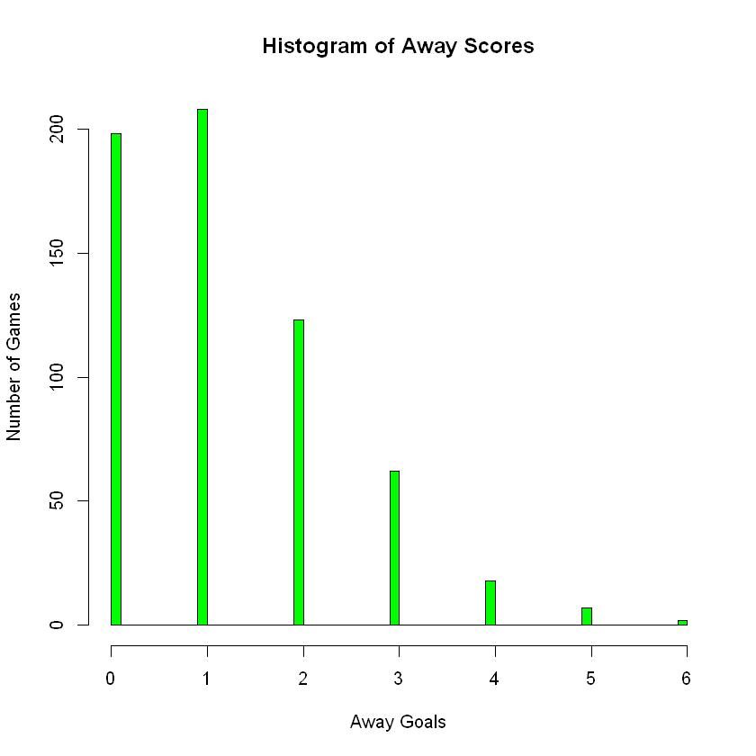

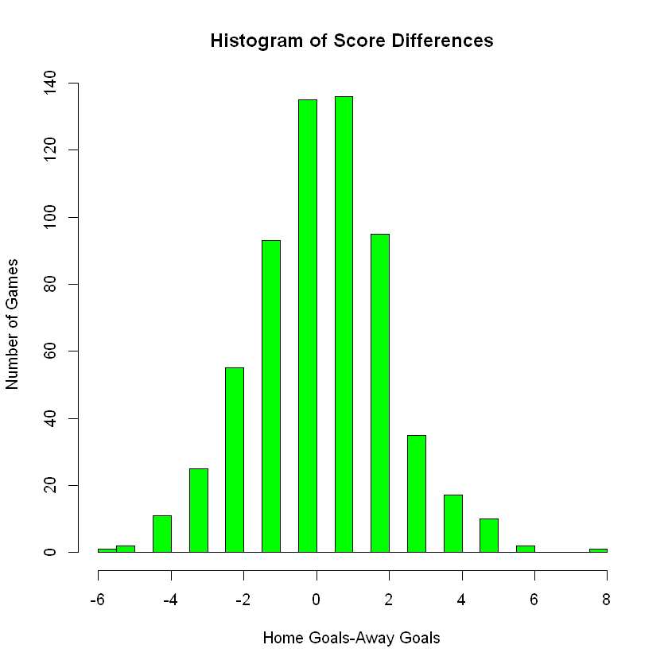

```r
hist_home_scores <- hist(finishedmatches$match_hometeam_score,
     breaks=50,
     main="Histogram of Home Scores",
     xlab="Home Goals",
     ylab="Number of Games",
     col="green"
     )
hist_away_scores <- hist(finishedmatches$match_awayteam_score,
     breaks=50,
     main="Histogram of Away Scores",
     xlab="Away Goals",
     ylab="Number of Games",
     col="green",)
hist_home_minus_away_scores <- hist(finishedmatches$match_hometeam_score-finishedmatches$match_awayteam_score,
     breaks=50,
     main="Histogram of Score Differences",
     xlab="Home Goals-Away Goals",
     ylab="Number of Games",
     col="green",)
```

After plotting the data, One can intuitively says that the scores data looks like the pmf of poisson distribution. In order to prove this assumption, I have plotted the lines that combines the real values of the poisson distribution with parameter mean of the sample.

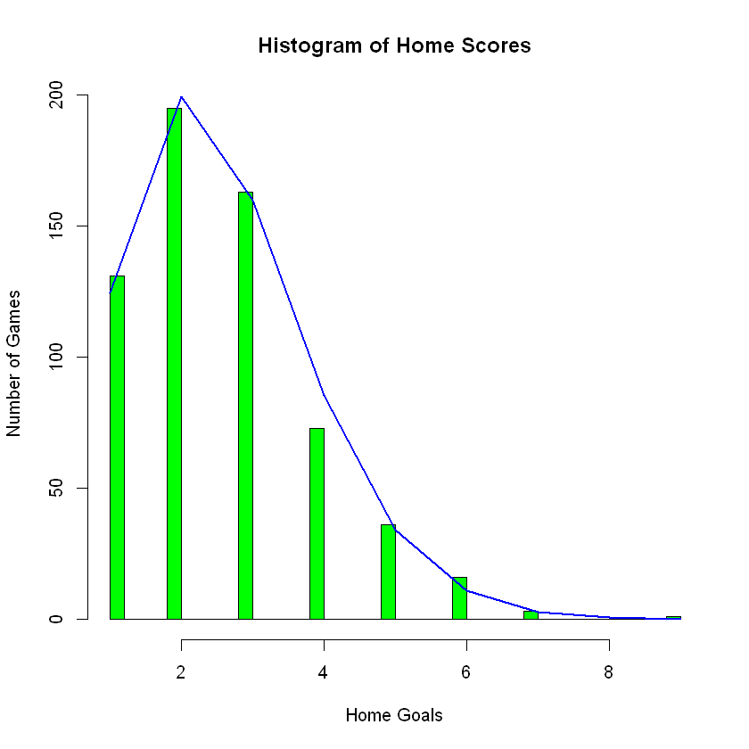

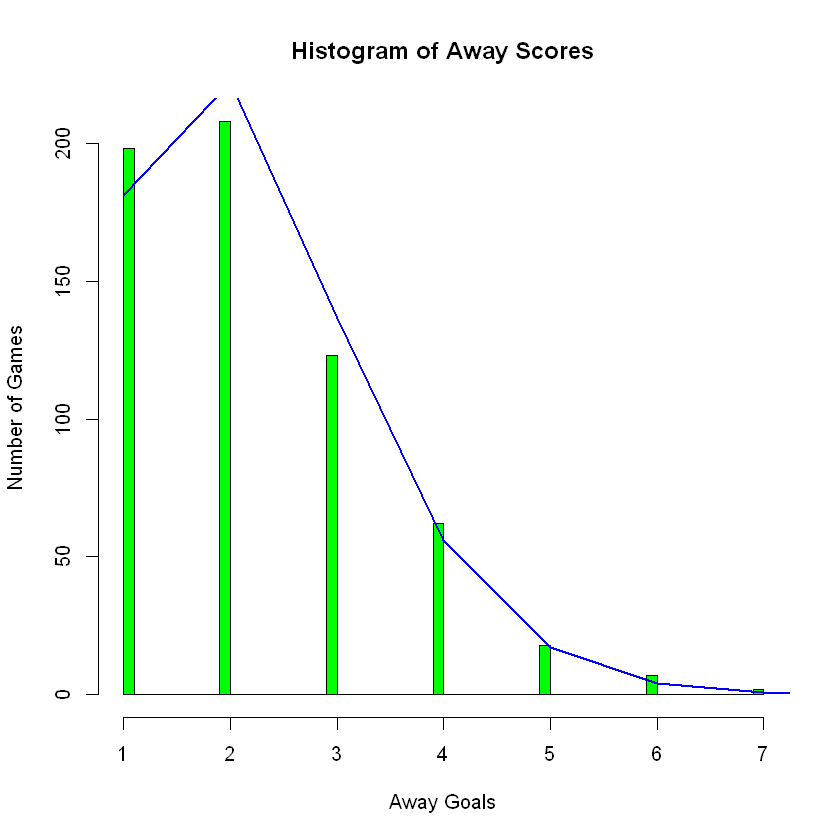

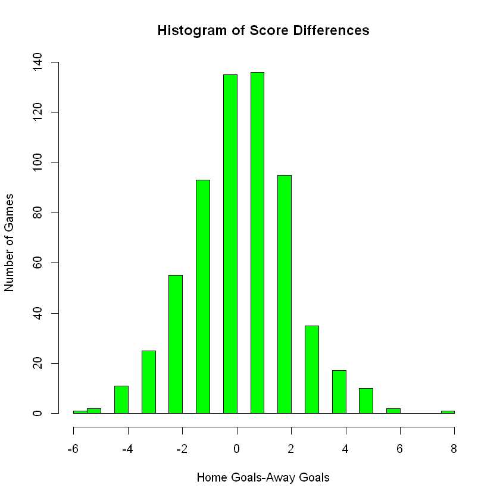

```r
x1<-finishedmatches$match_hometeam_score
x2<-finishedmatches$match_awayteam_score
hist_home_scores <- hist(finishedmatches$match_hometeam_score + 1,
     breaks=50,
     main="Histogram of Home Scores",
     xlab="Home Goals",
     ylab="Number of Games",
     col="green"
     )

dist = dpois(0:8, lambda =mean(finishedmatches$match_hometeam_score))
dist = dist * 618     #618 is the number of rows in the data frame
lines(dist, lwd= 2, col="blue")

hist_away_scores <- hist(finishedmatches$match_awayteam_score + 1,
     breaks=50,
     main="Histogram of Away Scores",
     xlab="Away Goals",
     ylab="Number of Games",
     col="green",)
dist2 = dpois(0:8, lambda =mean(finishedmatches$match_awayteam_score))
dist2 = dist2 * 618    #618 is the number of rows in the data frame
lines(dist2, lwd= 2, col="blue")

hist_home_minus_away_scores <- hist(finishedmatches$match_hometeam_score-finishedmatches$match_awayteam_score,
     breaks=50,
     main="Histogram of Score Differences",
     xlab="Home Goals-Away Goals",
     ylab="Number of Games",
     col="green",)
```

After observing the results, I have concluded that the sample data is very accordant with the poisson distribution.

# Task 2

In this part, the aim was to analyze the performance of the different bookmakers while determination of the odds of the games. I have used "bets" and the "matches" data to compare the real outcomes with the assumptions of the different bookmakers. Main goal was to find out if there is a strong evidence that one can beat the bookmakers in the long run betting to the result "draw". Firstly, I have taken the "bets" data and merge this data with the finished matches data in the first task.

```r
library(data.table)
betsall <- fread("bets.csv")
```

```r
bets <- merge(betsall, finishedmatches, by = "match_id")
```

Here the bets data had the extra betting conditions (i.e. total goals in the match will not exceed 3 ). The part that I have interested was to find the winner of the match. Hence, I filtered the bets and get the ones that are home team will win away team will win and the match will end with tie.

```r
allodds <- bets[bets$variable=="odd_1" | bets$variable=="odd_2" | bets$variable=="odd_x"]
```

There were so many different bookmakers in the data and I choose 5 of them that have relatively more data about the matches compared to the others. I have looked the following table and chosen the bookmakers.

```r
head(allodds[, .(odd_epoch = uniqueN(odd_epoch)), by = odd_bookmakers])
```

A data.table: 6 × 2

| odd_bookmakers <chr> | odd_epoch <int> |
| --- | --- |
| 1xBet | 368 |
| Marathonbet | 346 |
| bwin | 392 |
| 188BET | 324 |
| 18bet | 372 |
| 5Dimes | 166 |

The first bookmaker was "1xBet" and I filtered the odds of 1xBet.

```r
bookmaker_1xBet <- allodds[allodds$odd_bookmakers=="1xBet"]
```

Then I calculated the inverse values of the odds in order to calculate the probability that the bookmaker assumed. and sum all of the possible values in the match considering the fact that one bookmaker can change the odds during the match and there were more than one, for instance, P(home) values in a single match. The variable "odd_epoch" has specified the odd classes.

```r
bookmaker_1xBet$oneovervalue <- 1 / bookmaker_1xBet$value
sum_bookmaker_1xBet <- data.table(rowsum(bookmaker_1xBet$oneovervalue,bookmaker_1xBet$odd_epoch ), keep.rownames= TRUE)
names(sum_bookmaker_1xBet) <- c("odd_epoch","odds_sum")
sum_bookmaker_1xBet$odd_epoch <- as.numeric(as.character(sum_bookmaker_1xBet$odd_epoch))
```

Here, the bookmakers have certainly add a profit margin to the odds, therefore, when calculating the probabilities, sum of the 1/odds has to be 1 in order to calculate the probability more accurate. I have done the normalization below:

```r
pre_oddsum_bookmaker_1xBet <- merge(bookmaker_1xBet , sum_bookmaker_1xBet , by = "odd_epoch")
oddsum_bookmaker_1xBet <- merge(pre_oddsum_bookmaker_1xBet , finishedmatches , by = "match_id")
oddsum_bookmaker_1xBet$odds_prob <- oddsum_bookmaker_1xBet$oneovervalue / oddsum_bookmaker_1xBet$odds_sum
```

Then I have divide the table "oddsum_bookmaker_1xBet" according to the odd variable to plot the values easily. And plotted the P(home)-P(away) values and P(draw).

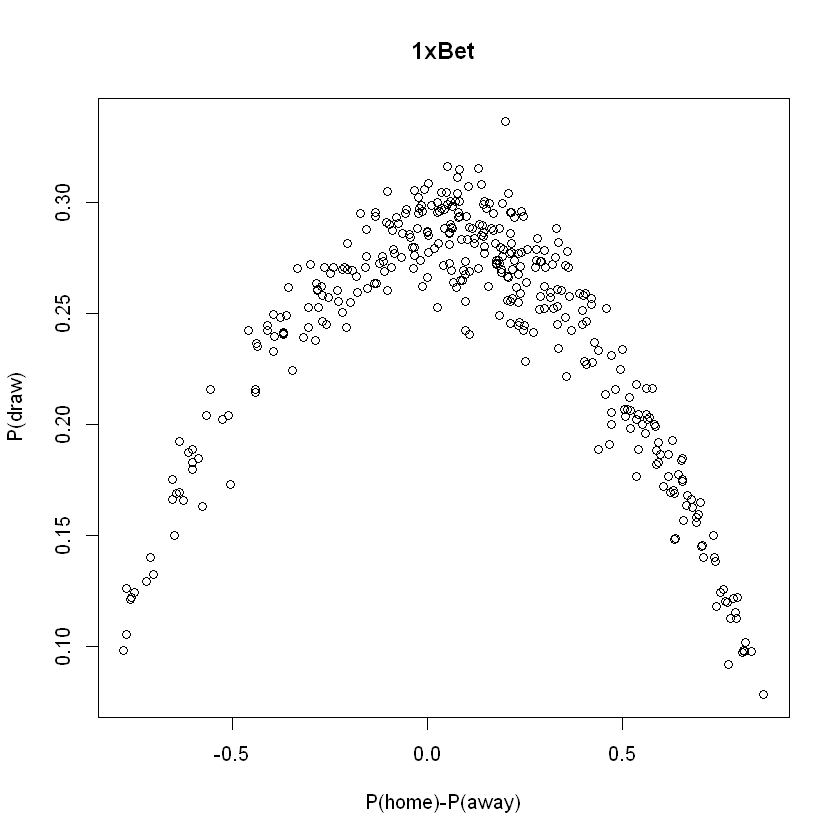

```r
draw_odd_bookmaker_1xBet <- oddsum_bookmaker_1xBet[oddsum_bookmaker_1xBet$variable=="odd_x"]
home_odd_bookmaker_1xBet <- oddsum_bookmaker_1xBet[oddsum_bookmaker_1xBet$variable=="odd_1"]
away_odd_bookmaker_1xBet <- oddsum_bookmaker_1xBet[oddsum_bookmaker_1xBet$variable=="odd_2"]
p_homeminusaway_1xbet <- home_odd_bookmaker_1xBet$odds_prob - away_odd_bookmaker_1xBet$odds_prob
plot(p_homeminusaway_1xbet, draw_odd_bookmaker_1xBet$odds_prob, main="1xBet", xlab="P(home)-P(away)", ylab="P(draw)")
```

The histogram of the frequencies of the results in the specified bins is as follows:

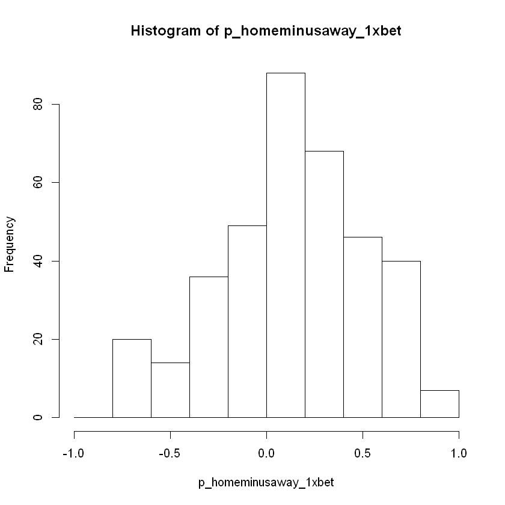

```r
allhist_1xBet <- hist(p_homeminusaway_1xbet, breaks=c(-1,-0.8,-0.6,-0.4,-0.2,0,0.2,0.4,0.6,0.8,1))
```

After finding he assumption of the bookmaker, I calculated the real probabilities for the bins (i.e. (-1,-0.8),(-0.8,-0,6),..) that the histogram above shows. Then I calculated the real matches that are resulted with "draw" and plot the histogram of the real values in order to get the real probability for draw.

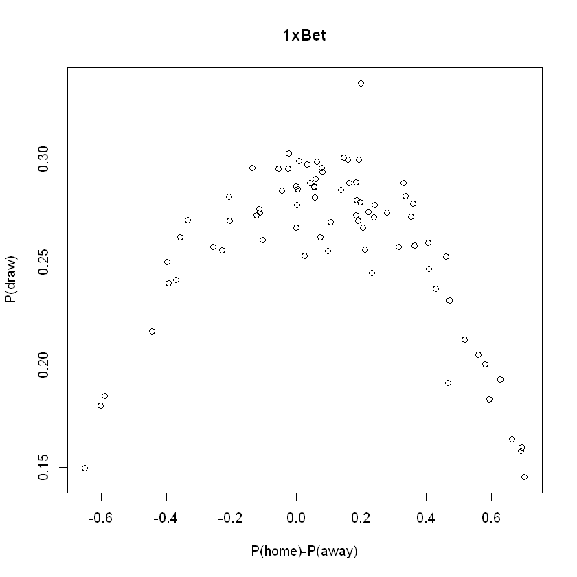

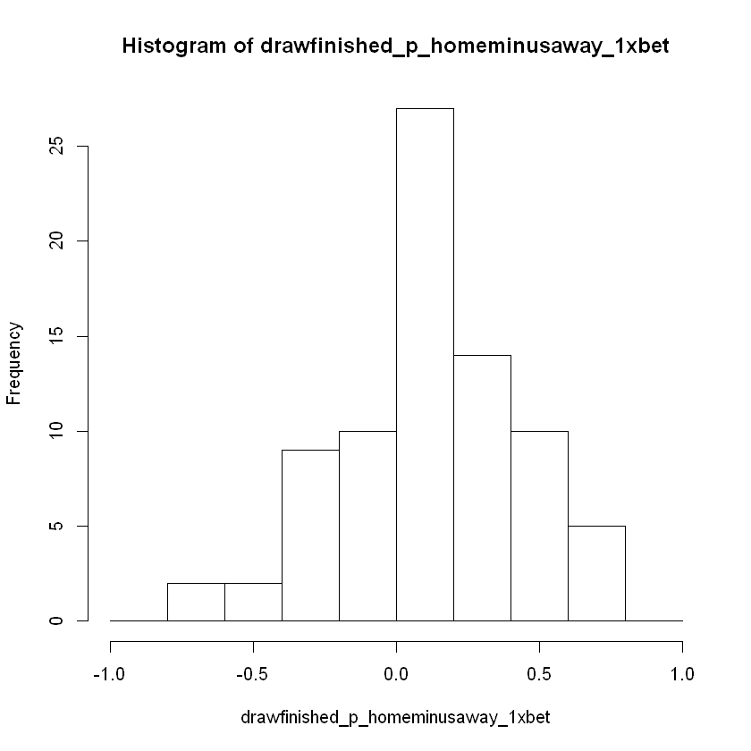

```r
drawfinished_1xBet<- oddsum_bookmaker_1xBet[oddsum_bookmaker_1xBet$match_hometeam_score.y==oddsum_bookmaker_1xBet$match_awayteam_score.y]
drawfinished_draw_odd_bookmaker_1xBet <- drawfinished_1xBet[drawfinished_1xBet$variable=="odd_x"]
drawfinished_home_odd_bookmaker_1xBet <- drawfinished_1xBet[drawfinished_1xBet$variable=="odd_1"]
drawfinished_away_odd_bookmaker_1xBet <- drawfinished_1xBet[drawfinished_1xBet$variable=="odd_2"]
drawfinished_p_homeminusaway_1xbet <- drawfinished_home_odd_bookmaker_1xBet$odds_prob - drawfinished_away_odd_bookmaker_1xBet$odds_prob
plot(drawfinished_p_homeminusaway_1xbet, drawfinished_draw_odd_bookmaker_1xBet$odds_prob, main="1xBet", xlab="P(home)-P(away)", ylab="P(draw)")
histdrawfinished_1xBet <- hist(drawfinished_p_homeminusaway_1xbet, breaks=c(-1,-0.8,-0.6,-0.4,-0.2,0,0.2,0.4,0.6,0.8,1))
```

Lastly, I have divide two histograms and marked the real values with red colour. The comparison of the two porbibilities are in the following plot.

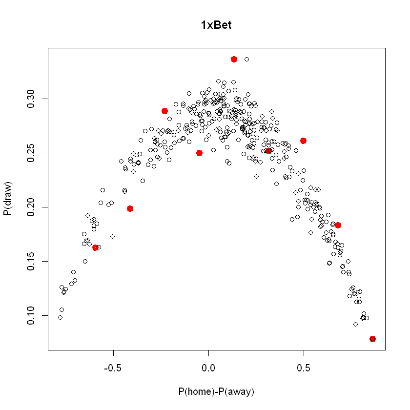

```r
plot(histdrawfinished_1xBet$counts/allhist_1xBet$counts, col = "red", lwd=5, xlab="", ylab="", axes=FALSE)
par(new=TRUE)
plot(p_homeminusaway_1xbet, draw_odd_bookmaker_1xBet$odds_prob, main="1xBet", xlab="P(home)-P(away)", ylab="P(draw)")
```

For the bookmaker 1xBet, the results show that in the long run, one can make money by betting "draw" to the matches that has smaller odds for home team and larger odds for the away team.

I have done the same iterations for the other bookmakers "18bet","BetVictor","bet-at-home" and "bwin"

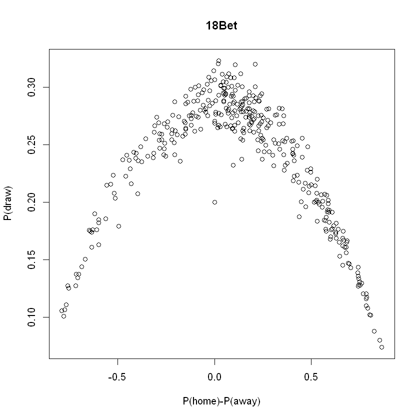

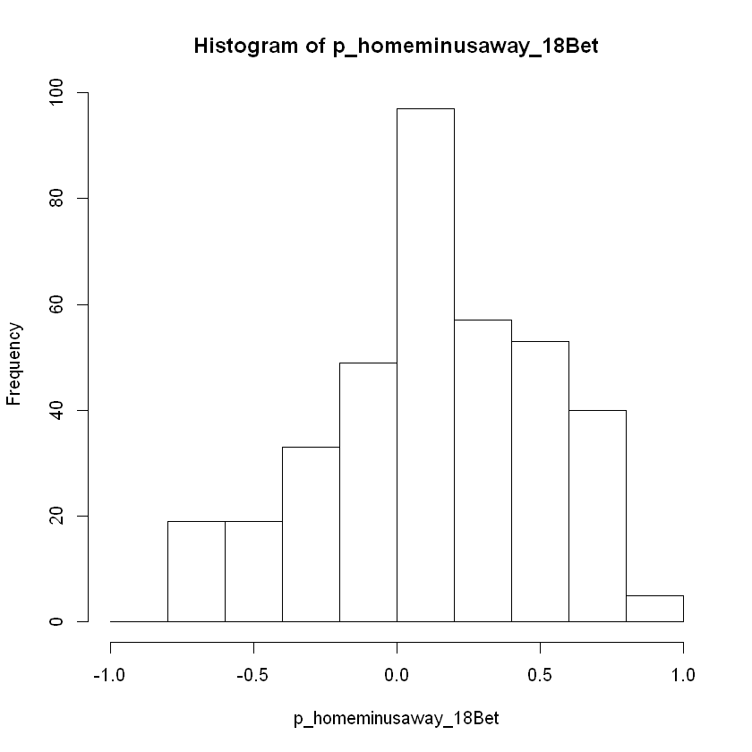

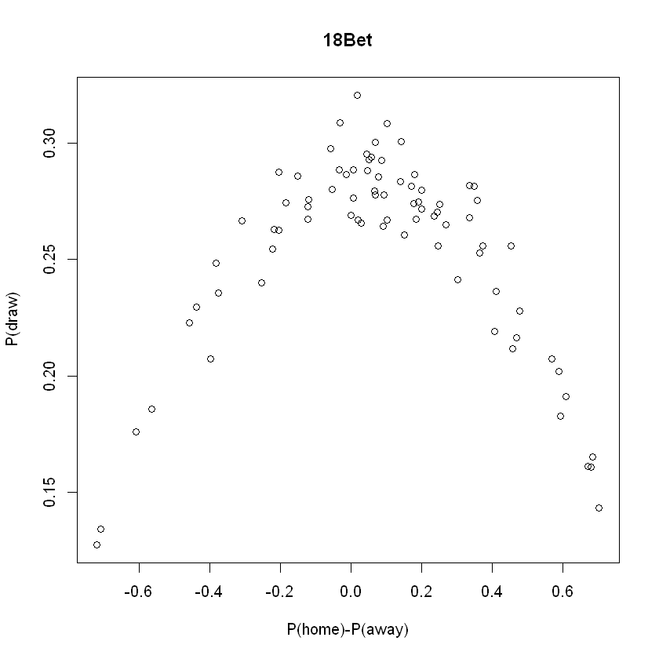

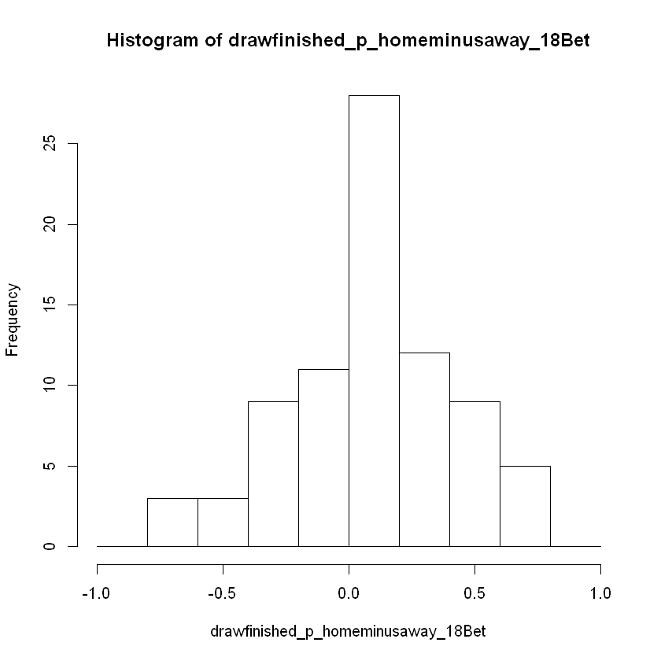

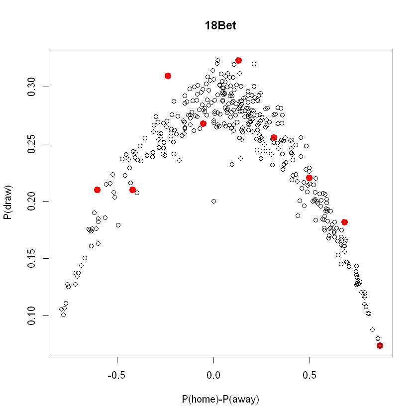

```r
bookmaker_18Bet <- allodds[allodds$odd_bookmakers=="18bet"]
bookmaker_18Bet$oneovervalue <- 1 / bookmaker_18Bet$value
sum_bookmaker_18Bet <- data.table(rowsum(bookmaker_18Bet$oneovervalue,bookmaker_18Bet$odd_epoch ), keep.rownames= TRUE)
names(sum_bookmaker_18Bet) <- c("odd_epoch","odds_sum")
sum_bookmaker_18Bet$odd_epoch <- as.numeric(as.character(sum_bookmaker_18Bet$odd_epoch))
pre_oddsum_bookmaker_18Bet <- merge(bookmaker_18Bet , sum_bookmaker_18Bet , by = "odd_epoch")
oddsum_bookmaker_18Bet <- merge(pre_oddsum_bookmaker_18Bet , finishedmatches , by = "match_id")
oddsum_bookmaker_18Bet$odds_prob <- oddsum_bookmaker_18Bet$oneovervalue / oddsum_bookmaker_18Bet$odds_sum
draw_odd_bookmaker_18Bet <- oddsum_bookmaker_18Bet[oddsum_bookmaker_18Bet$variable=="odd_x"]
home_odd_bookmaker_18Bet <- oddsum_bookmaker_18Bet[oddsum_bookmaker_18Bet$variable=="odd_1"]
away_odd_bookmaker_18Bet <- oddsum_bookmaker_18Bet[oddsum_bookmaker_18Bet$variable=="odd_2"]
p_homeminusaway_18Bet <- home_odd_bookmaker_18Bet$odds_prob - away_odd_bookmaker_18Bet$odds_prob
plot(p_homeminusaway_18Bet, draw_odd_bookmaker_18Bet$odds_prob, main="18Bet", xlab="P(home)-P(away)", ylab="P(draw)")
allhist_18Bet <- hist(p_homeminusaway_18Bet, breaks=c(-1,-0.8,-0.6,-0.4,-0.2,0,0.2,0.4,0.6,0.8,1))
drawfinished_18Bet<- oddsum_bookmaker_18Bet[oddsum_bookmaker_18Bet$match_hometeam_score.y==oddsum_bookmaker_18Bet$match_awayteam_score.y]
drawfinished_draw_odd_bookmaker_18Bet <- drawfinished_18Bet[drawfinished_18Bet$variable=="odd_x"]
drawfinished_home_odd_bookmaker_18Bet <- drawfinished_18Bet[drawfinished_18Bet$variable=="odd_1"]
drawfinished_away_odd_bookmaker_18Bet <- drawfinished_18Bet[drawfinished_18Bet$variable=="odd_2"]
drawfinished_p_homeminusaway_18Bet <- drawfinished_home_odd_bookmaker_18Bet$odds_prob - drawfinished_away_odd_bookmaker_18Bet$odds_prob
plot(drawfinished_p_homeminusaway_18Bet, drawfinished_draw_odd_bookmaker_18Bet$odds_prob, main="18Bet", xlab="P(home)-P(away)", ylab="P(draw)")
histdrawfinished_18Bet <- hist(drawfinished_p_homeminusaway_18Bet, breaks=c(-1,-0.8,-0.6,-0.4,-0.2,0,0.2,0.4,0.6,0.8,1))
plot(histdrawfinished_18Bet$counts/allhist_18Bet$counts, col = "red", lwd=5, xlab="", ylab="", axes=FALSE)
par(new=TRUE)
plot(p_homeminusaway_18Bet, draw_odd_bookmaker_18Bet$odds_prob, main="18Bet", xlab="P(home)-P(away)", ylab="P(draw)")
```

Unlike 1xBet, long run profit can be made by betting matches that have very close home and away odds and lower away odd.

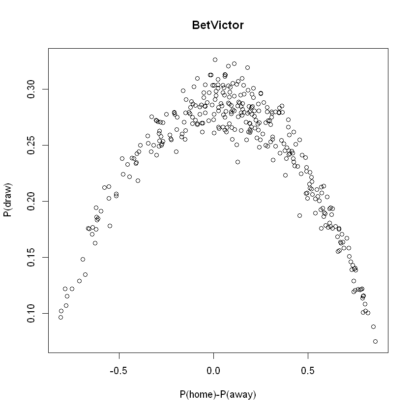

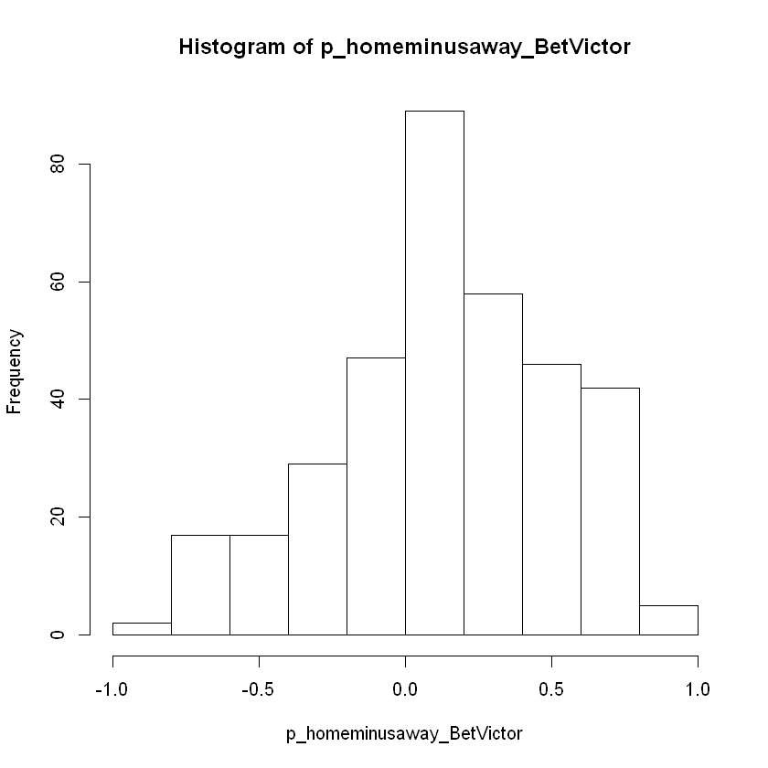

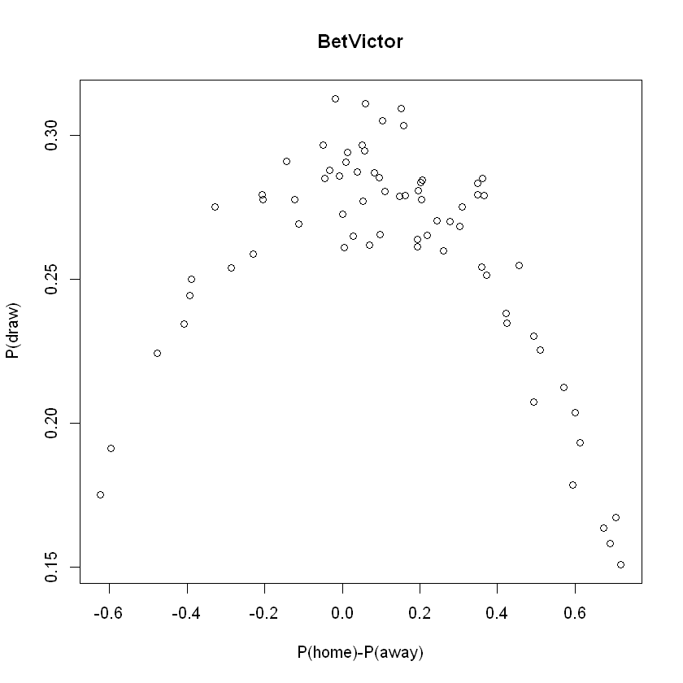

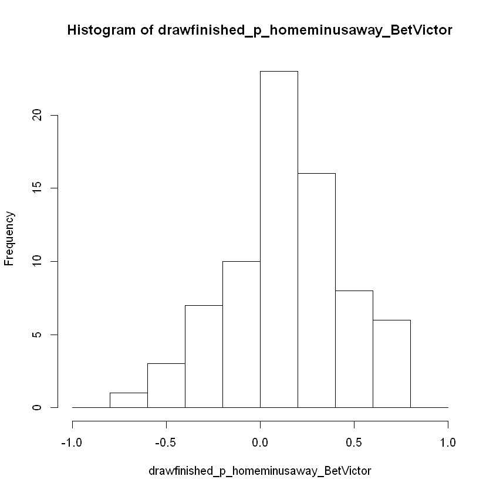

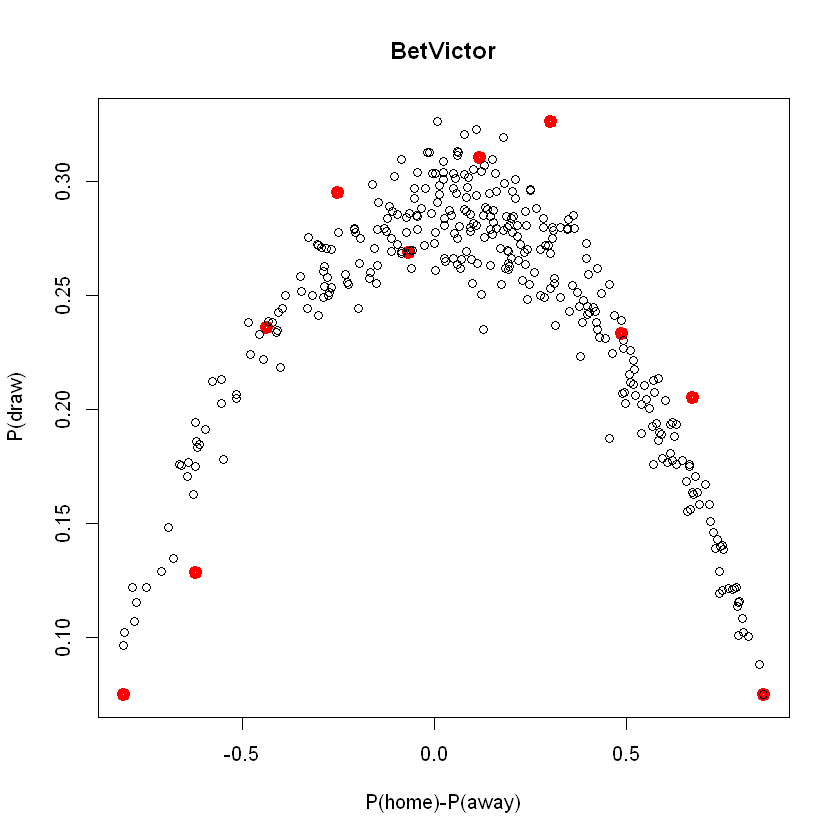

```r
bookmaker_BetVictor <- allodds[allodds$odd_bookmakers=="BetVictor"]
bookmaker_BetVictor$oneovervalue <- 1 / bookmaker_BetVictor$value
sum_bookmaker_BetVictor <- data.table(rowsum(bookmaker_BetVictor$oneovervalue,bookmaker_BetVictor$odd_epoch ), keep.rownames= TRUE)
names(sum_bookmaker_BetVictor) <- c("odd_epoch","odds_sum")
sum_bookmaker_BetVictor$odd_epoch <- as.numeric(as.character(sum_bookmaker_BetVictor$odd_epoch))
pre_oddsum_bookmaker_BetVictor <- merge(bookmaker_BetVictor , sum_bookmaker_BetVictor , by = "odd_epoch")
oddsum_bookmaker_BetVictor <- merge(pre_oddsum_bookmaker_BetVictor , finishedmatches , by = "match_id")
oddsum_bookmaker_BetVictor$odds_prob <- oddsum_bookmaker_BetVictor$oneovervalue / oddsum_bookmaker_BetVictor$odds_sum
draw_odd_bookmaker_BetVictor <- oddsum_bookmaker_BetVictor[oddsum_bookmaker_BetVictor$variable=="odd_x"]
home_odd_bookmaker_BetVictor <- oddsum_bookmaker_BetVictor[oddsum_bookmaker_BetVictor$variable=="odd_1"]
away_odd_bookmaker_BetVictor <- oddsum_bookmaker_BetVictor[oddsum_bookmaker_BetVictor$variable=="odd_2"]
p_homeminusaway_BetVictor <- home_odd_bookmaker_BetVictor$odds_prob - away_odd_bookmaker_BetVictor$odds_prob
plot(p_homeminusaway_BetVictor, draw_odd_bookmaker_BetVictor$odds_prob, main="BetVictor", xlab="P(home)-P(away)", ylab="P(draw)")
allhist_BetVictor <- hist(p_homeminusaway_BetVictor, breaks=c(-1,-0.8,-0.6,-0.4,-0.2,0,0.2,0.4,0.6,0.8,1))
drawfinished_BetVictor<- oddsum_bookmaker_BetVictor[oddsum_bookmaker_BetVictor$match_hometeam_score.y==oddsum_bookmaker_BetVictor$match_awayteam_score.y]
drawfinished_draw_odd_bookmaker_BetVictor <- drawfinished_BetVictor[drawfinished_BetVictor$variable=="odd_x"]
drawfinished_home_odd_bookmaker_BetVictor <- drawfinished_BetVictor[drawfinished_BetVictor$variable=="odd_1"]
drawfinished_away_odd_bookmaker_BetVictor <- drawfinished_BetVictor[drawfinished_BetVictor$variable=="odd_2"]
drawfinished_p_homeminusaway_BetVictor <- drawfinished_home_odd_bookmaker_BetVictor$odds_prob - drawfinished_away_odd_bookmaker_BetVictor$odds_prob
plot(drawfinished_p_homeminusaway_BetVictor, drawfinished_draw_odd_bookmaker_BetVictor$odds_prob, main="BetVictor", xlab="P(home)-P(away)", ylab="P(draw)")
histdrawfinished_BetVictor <- hist(drawfinished_p_homeminusaway_BetVictor, breaks=c(-1,-0.8,-0.6,-0.4,-0.2,0,0.2,0.4,0.6,0.8,1))
plot(histdrawfinished_BetVictor$counts/allhist_BetVictor$counts, col = "red", lwd=5, xlab="", ylab="", axes=FALSE)
par(new=TRUE)
plot(p_homeminusaway_BetVictor, draw_odd_bookmaker_BetVictor$odds_prob, main="BetVictor", xlab="P(home)-P(away)", ylab="P(draw)")
```

Bookmaker "BetVictor" also provides some profit options for the matches that have smaller home odds and close home and away odds.

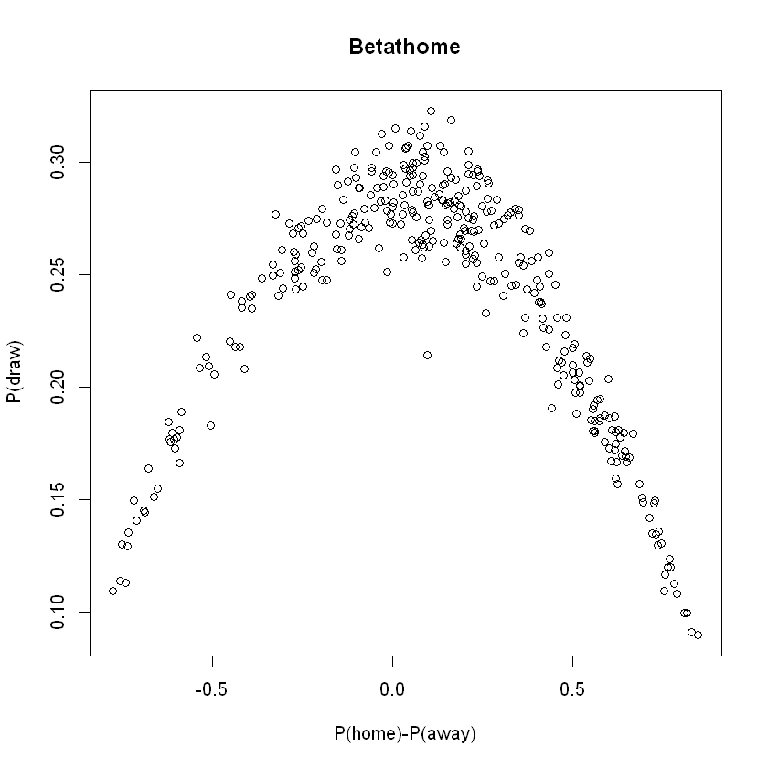

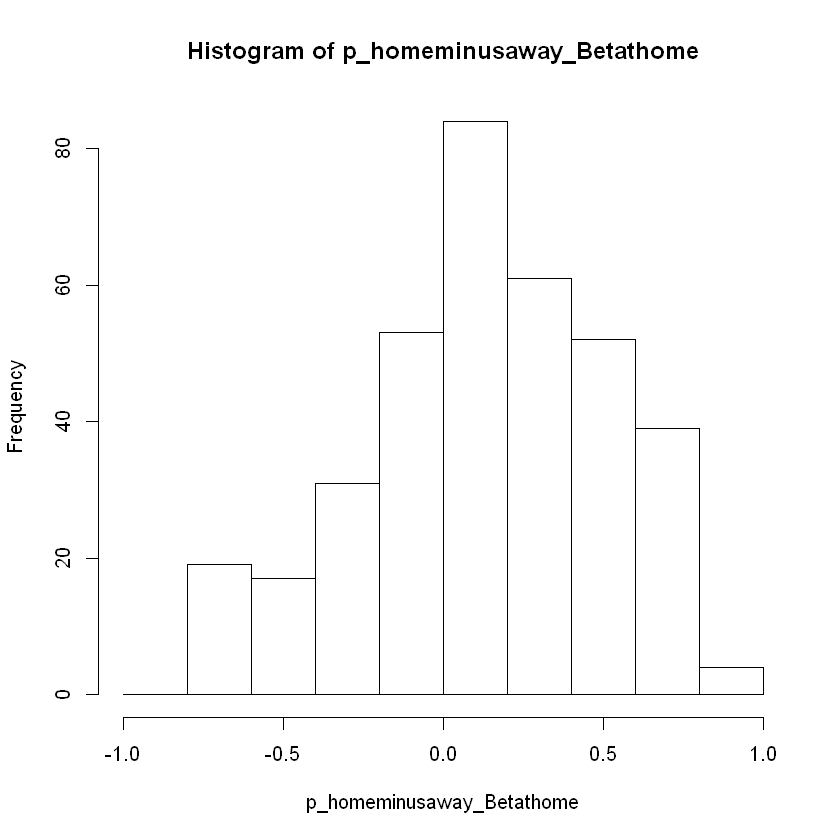

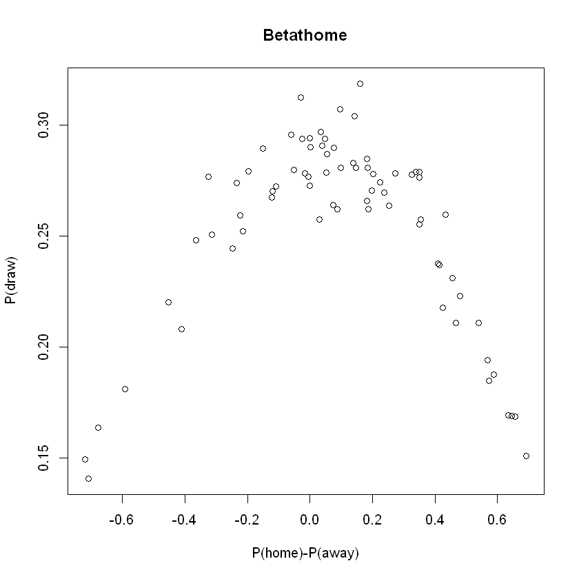

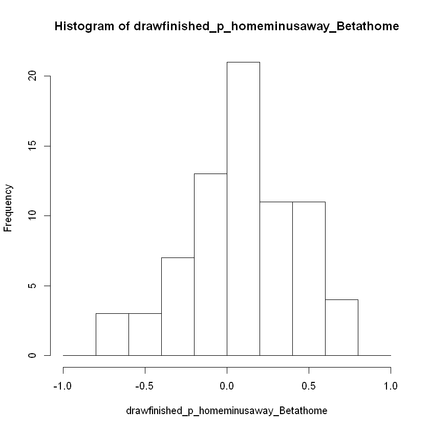

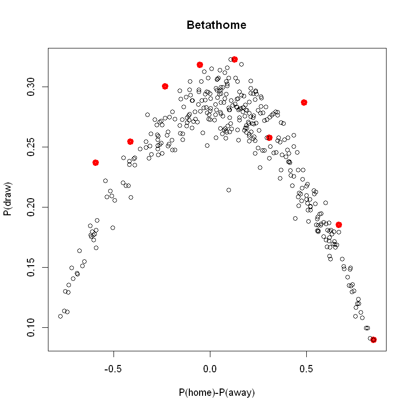

```r
bookmaker_Betathome <- allodds[allodds$odd_bookmakers=="bet-at-home"]
bookmaker_Betathome$oneovervalue <- 1 / bookmaker_Betathome$value
sum_bookmaker_Betathome <- data.table(rowsum(bookmaker_Betathome$oneovervalue,bookmaker_Betathome$odd_epoch ), keep.rownames= TRUE)
names(sum_bookmaker_Betathome) <- c("odd_epoch","odds_sum")
sum_bookmaker_Betathome$odd_epoch <- as.numeric(as.character(sum_bookmaker_Betathome$odd_epoch))
pre_oddsum_bookmaker_Betathome <- merge(bookmaker_Betathome , sum_bookmaker_Betathome , by = "odd_epoch")
oddsum_bookmaker_Betathome <- merge(pre_oddsum_bookmaker_Betathome , finishedmatches , by = "match_id")
oddsum_bookmaker_Betathome$odds_prob <- oddsum_bookmaker_Betathome$oneovervalue / oddsum_bookmaker_Betathome$odds_sum
draw_odd_bookmaker_Betathome <- oddsum_bookmaker_Betathome[oddsum_bookmaker_Betathome$variable=="odd_x"]
home_odd_bookmaker_Betathome <- oddsum_bookmaker_Betathome[oddsum_bookmaker_Betathome$variable=="odd_1"]
away_odd_bookmaker_Betathome <- oddsum_bookmaker_Betathome[oddsum_bookmaker_Betathome$variable=="odd_2"]
p_homeminusaway_Betathome <- home_odd_bookmaker_Betathome$odds_prob - away_odd_bookmaker_Betathome$odds_prob
plot(p_homeminusaway_Betathome, draw_odd_bookmaker_Betathome$odds_prob, main="Betathome", xlab="P(home)-P(away)", ylab="P(draw)")
allhist_Betathome <- hist(p_homeminusaway_Betathome, breaks=c(-1,-0.8,-0.6,-0.4,-0.2,0,0.2,0.4,0.6,0.8,1))
drawfinished_Betathome<- oddsum_bookmaker_Betathome[oddsum_bookmaker_Betathome$match_hometeam_score.y==oddsum_bookmaker_Betathome$match_awayteam_score.y]
drawfinished_draw_odd_bookmaker_Betathome <- drawfinished_Betathome[drawfinished_Betathome$variable=="odd_x"]
drawfinished_home_odd_bookmaker_Betathome <- drawfinished_Betathome[drawfinished_Betathome$variable=="odd_1"]
drawfinished_away_odd_bookmaker_Betathome <- drawfinished_Betathome[drawfinished_Betathome$variable=="odd_2"]
drawfinished_p_homeminusaway_Betathome <- drawfinished_home_odd_bookmaker_Betathome$odds_prob - drawfinished_away_odd_bookmaker_Betathome$odds_prob
plot(drawfinished_p_homeminusaway_Betathome, drawfinished_draw_odd_bookmaker_Betathome$odds_prob, main="Betathome", xlab="P(home)-P(away)", ylab="P(draw)")
histdrawfinished_Betathome <- hist(drawfinished_p_homeminusaway_Betathome, breaks=c(-1,-0.8,-0.6,-0.4,-0.2,0,0.2,0.4,0.6,0.8,1))
plot(histdrawfinished_Betathome$counts/allhist_Betathome$counts, col = "red", lwd=5, xlab="", ylab="", axes=FALSE)
par(new=TRUE)
plot(p_homeminusaway_Betathome, draw_odd_bookmaker_Betathome$odds_prob, main="Betathome", xlab="P(home)-P(away)", ylab="P(draw)")
```

Among these bookmakers, the most preferable one for a customer is clearly "Bet-at-Home" that has very large odds for the teams. In the long run, one can win by betting as "draw" for almost all of the matches.

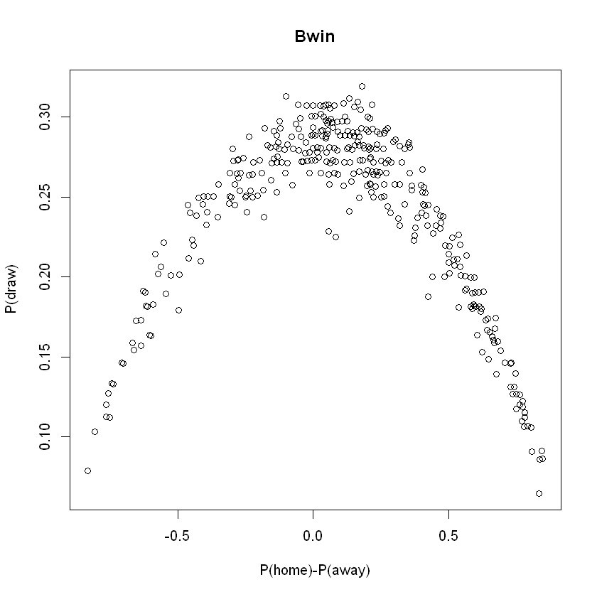

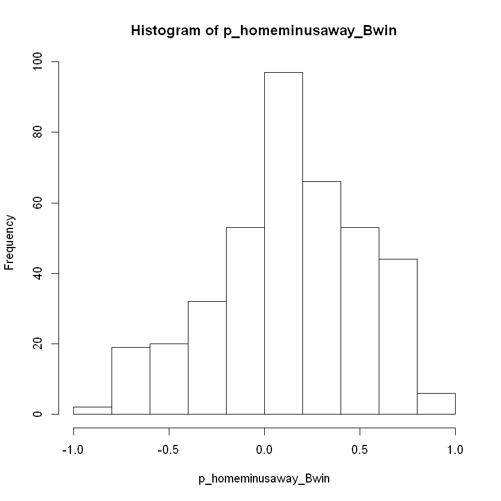

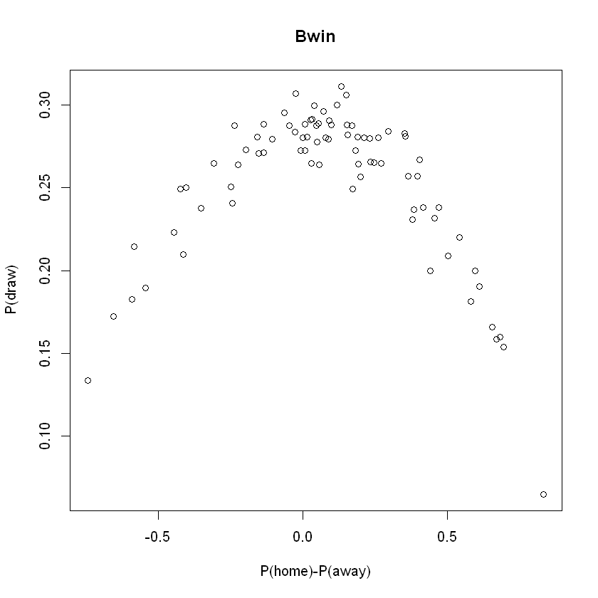

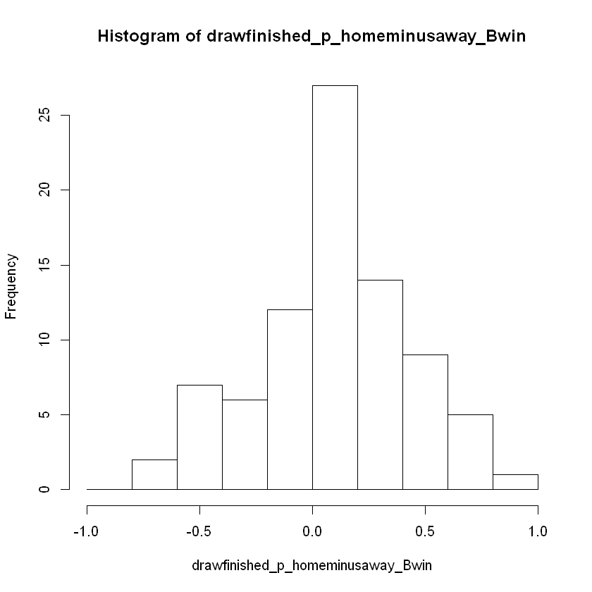

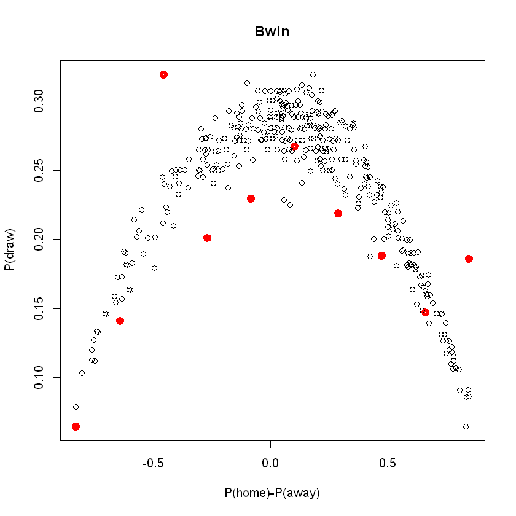

```r
bookmaker_Bwin <- allodds[allodds$odd_bookmakers=="bwin"]
bookmaker_Bwin$oneovervalue <- 1 / bookmaker_Bwin$value
sum_bookmaker_Bwin <- data.table(rowsum(bookmaker_Bwin$oneovervalue,bookmaker_Bwin$odd_epoch ), keep.rownames= TRUE)
names(sum_bookmaker_Bwin) <- c("odd_epoch","odds_sum")
sum_bookmaker_Bwin$odd_epoch <- as.numeric(as.character(sum_bookmaker_Bwin$odd_epoch))
pre_oddsum_bookmaker_Bwin <- merge(bookmaker_Bwin , sum_bookmaker_Bwin , by = "odd_epoch")
oddsum_bookmaker_Bwin <- merge(pre_oddsum_bookmaker_Bwin , finishedmatches , by = "match_id")
oddsum_bookmaker_Bwin$odds_prob <- oddsum_bookmaker_Bwin$oneovervalue / oddsum_bookmaker_Bwin$odds_sum
draw_odd_bookmaker_Bwin <- oddsum_bookmaker_Bwin[oddsum_bookmaker_Bwin$variable=="odd_x"]
home_odd_bookmaker_Bwin <- oddsum_bookmaker_Bwin[oddsum_bookmaker_Bwin$variable=="odd_1"]
away_odd_bookmaker_Bwin <- oddsum_bookmaker_Bwin[oddsum_bookmaker_Bwin$variable=="odd_2"]
p_homeminusaway_Bwin <- home_odd_bookmaker_Bwin$odds_prob - away_odd_bookmaker_Bwin$odds_prob
plot(p_homeminusaway_Bwin, draw_odd_bookmaker_Bwin$odds_prob, main="Bwin", xlab="P(home)-P(away)", ylab="P(draw)")
allhist_Bwin <- hist(p_homeminusaway_Bwin, breaks=c(-1,-0.8,-0.6,-0.4,-0.2,0,0.2,0.4,0.6,0.8,1))
drawfinished_Bwin<- oddsum_bookmaker_Bwin[oddsum_bookmaker_Bwin$match_hometeam_score.y==oddsum_bookmaker_Bwin$match_awayteam_score.y]
drawfinished_draw_odd_bookmaker_Bwin <- drawfinished_Bwin[drawfinished_Bwin$variable=="odd_x"]
drawfinished_home_odd_bookmaker_Bwin <- drawfinished_Bwin[drawfinished_Bwin$variable=="odd_1"]
drawfinished_away_odd_bookmaker_Bwin <- drawfinished_Bwin[drawfinished_Bwin$variable=="odd_2"]
drawfinished_p_homeminusaway_Bwin <- drawfinished_home_odd_bookmaker_Bwin$odds_prob - drawfinished_away_odd_bookmaker_Bwin$odds_prob
plot(drawfinished_p_homeminusaway_Bwin, drawfinished_draw_odd_bookmaker_Bwin$odds_prob, main="Bwin", xlab="P(home)-P(away)", ylab="P(draw)")
histdrawfinished_Bwin <- hist(drawfinished_p_homeminusaway_Bwin, breaks=c(-1,-0.8,-0.6,-0.4,-0.2,0,0.2,0.4,0.6,0.8,1))
plot(histdrawfinished_Bwin$counts/allhist_Bwin$counts, col = "red", lwd=5, xlab="", ylab="", axes=FALSE)
par(new=TRUE)
plot(p_homeminusaway_Bwin, draw_odd_bookmaker_Bwin$odds_prob, main="Bwin", xlab="P(home)-P(away)", ylab="P(draw)")
```

# Task 3

In the last part of the Homework, it is required to prevent the effect of the outlier matches in order to make the data clear and performing the same performance tests as in the 2nd task. I have extracted the outlier data that is classified in the assignment by the following iterations.

```r
stats <- read.csv("stats.csv")
goals <- read.csv("goals.csv")
booking <- read.csv("booking.csv")
```

```r
extremegoals <- goals[goals$time %like% "90",]
allmatchess_extreme_goals <- merge(extremegoals,matches[matches$league_id=="148",], by ="match_id")
```

```r
allmatches_extremegoalsaffect<-allmatchess_extreme_goals[allmatchess_extreme_goals$match_awayteam_score-allmatchess_extreme_goals$match_hometeam_score<=1 && allmatchess$match_awayteam_score-allmatchess$match_hometeam_score>=-1,]
matches_after_extremegoals<-finishedmatches[!finishedmatches$match_id %in% allmatches_extremegoalsaffect$match_id,]
```

```r
matches_after_extremegoals_having_early_redcard<-merge(matches_after_extremegoals,booking[booking$card=="red card" & booking$time %in% c(0,1,2,3,4,5,6,7,8,9,10,11,12,13,14,15),], by ="match_id")
matches_after_extremegoals_and_red_card<-matches_after_extremegoals[!matches_after_extremegoals$match_id %in% matches_after_extremegoals_having_early_redcard$match_id,]
```

```r
newbets <- merge(betsall, matches_after_extremegoals_and_red_cards, by = "match_id")

alloddsne <- newbets[newbets$variable=="odd_1" | newbets$variable=="odd_2" | newbets$variable=="odd_x"]
alloddsnew <- alloddsne[alloddsne$league_id=="148"]
```

I have used the same code block from task 2 to plot the filtered results.

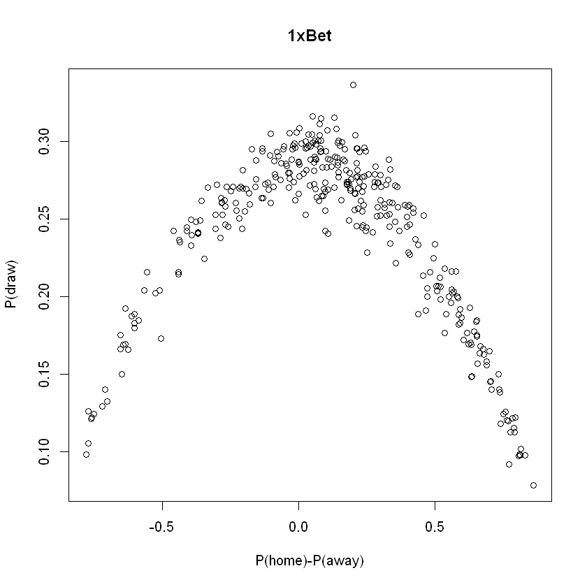

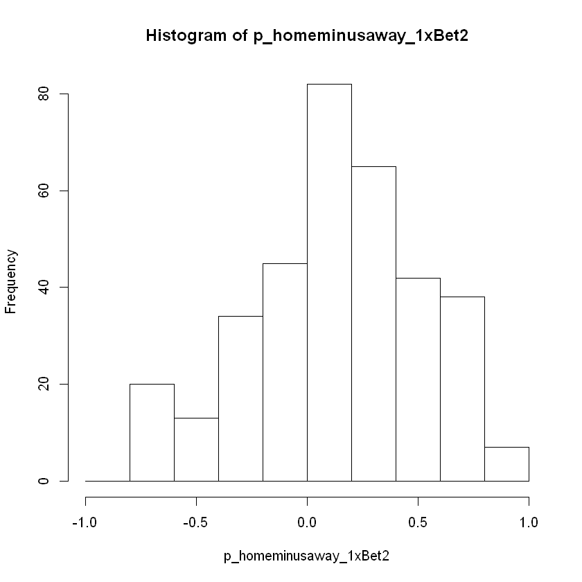

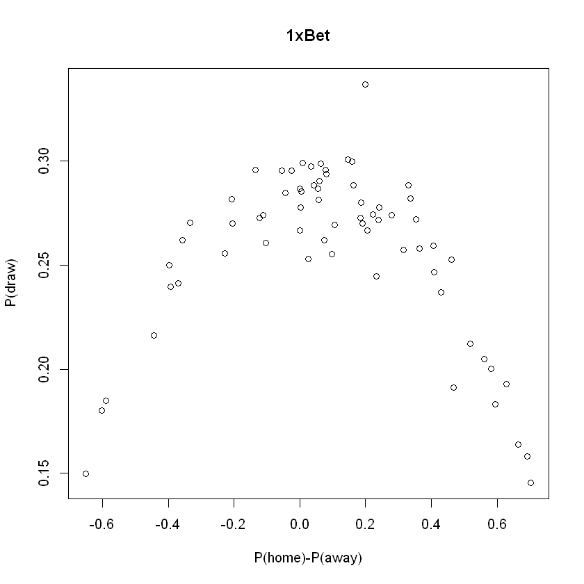

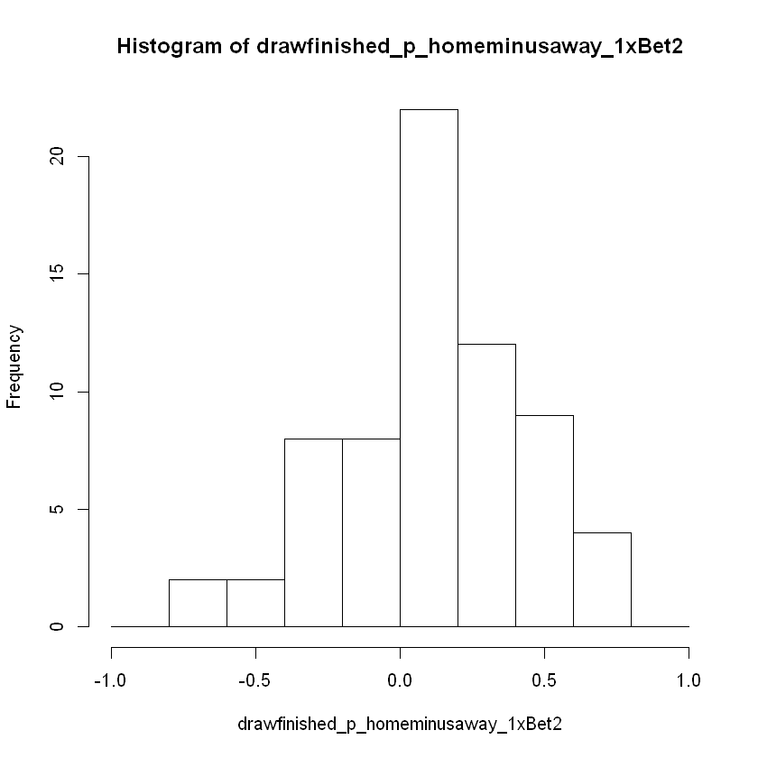

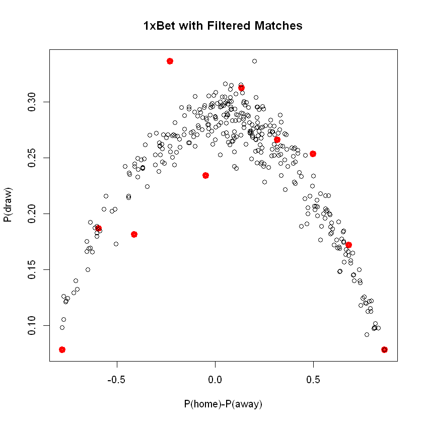

```r
bookmaker_1xBet2 <- alloddsnew[alloddsnew$odd_bookmakers=="1xBet"]
bookmaker_1xBet2$oneovervalue <- 1 / bookmaker_1xBet2$value
sum_bookmaker_1xBet2 <- data.table(rowsum(bookmaker_1xBet2$oneovervalue,bookmaker_1xBet2$odd_epoch ), keep.rownames= TRUE)
names(sum_bookmaker_1xBet2) <- c("odd_epoch","odds_sum")
sum_bookmaker_1xBet2$odd_epoch <- as.numeric(as.character(sum_bookmaker_1xBet2$odd_epoch))
pre_oddsum_bookmaker_1xBet2 <- merge(bookmaker_1xBet2 , sum_bookmaker_1xBet2 , by = "odd_epoch")
oddsum_bookmaker_1xBet2 <- merge(pre_oddsum_bookmaker_1xBet2 , matches_after_extremegoals_and_red_cards , by = "match_id")
oddsum_bookmaker_1xBet2$odds_prob <- oddsum_bookmaker_1xBet2$oneovervalue / oddsum_bookmaker_1xBet2$odds_sum
draw_odd_bookmaker_1xBet2 <- oddsum_bookmaker_1xBet2[oddsum_bookmaker_1xBet2$variable=="odd_x"]
home_odd_bookmaker_1xBet2 <- oddsum_bookmaker_1xBet2[oddsum_bookmaker_1xBet2$variable=="odd_1"]
away_odd_bookmaker_1xBet2 <- oddsum_bookmaker_1xBet2[oddsum_bookmaker_1xBet2$variable=="odd_2"]
p_homeminusaway_1xBet2 <- home_odd_bookmaker_1xBet2$odds_prob - away_odd_bookmaker_1xBet2$odds_prob
plot(p_homeminusaway_1xBet2, draw_odd_bookmaker_1xBet2$odds_prob, main="1xBet", xlab="P(home)-P(away)", ylab="P(draw)")
allhist_1xBet2 <- hist(p_homeminusaway_1xBet2, breaks=c(-1,-0.8,-0.6,-0.4,-0.2,0,0.2,0.4,0.6,0.8,1))
drawfinished_1xBet2<- oddsum_bookmaker_1xBet2[oddsum_bookmaker_1xBet2$match_hometeam_score.y==oddsum_bookmaker_1xBet2$match_awayteam_score.y]
drawfinished_draw_odd_bookmaker_1xBet2 <- drawfinished_1xBet2[drawfinished_1xBet2$variable=="odd_x"]
drawfinished_home_odd_bookmaker_1xBet2 <- drawfinished_1xBet2[drawfinished_1xBet2$variable=="odd_1"]
drawfinished_away_odd_bookmaker_1xBet2 <- drawfinished_1xBet2[drawfinished_1xBet2$variable=="odd_2"]
drawfinished_p_homeminusaway_1xBet2 <- drawfinished_home_odd_bookmaker_1xBet2$odds_prob - drawfinished_away_odd_bookmaker_1xBet2$odds_prob
plot(drawfinished_p_homeminusaway_1xBet2, drawfinished_draw_odd_bookmaker_1xBet2$odds_prob, main="1xBet", xlab="P(home)-P(away)", ylab="P(draw)")
histdrawfinished_1xBet2 <- hist(drawfinished_p_homeminusaway_1xBet2, breaks=c(-1,-0.8,-0.6,-0.4,-0.2,0,0.2,0.4,0.6,0.8,1))
plot(histdrawfinished_1xBet2$counts/allhist_Bwin$counts, col = "red", lwd=5, xlab="", ylab="", axes=FALSE)
par(new=TRUE)
plot(p_homeminusaway_1xBet2, draw_odd_bookmaker_1xBet2$odds_prob, main="1xBet with Filtered Matches", xlab="P(home)-P(away)", ylab="P(draw)")
```

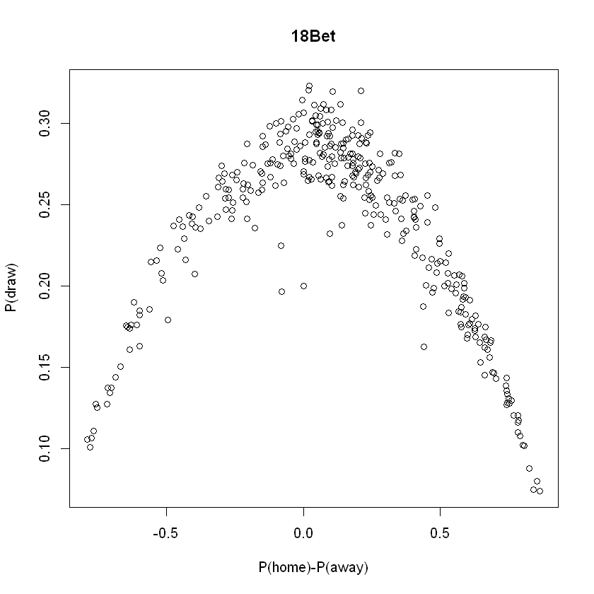

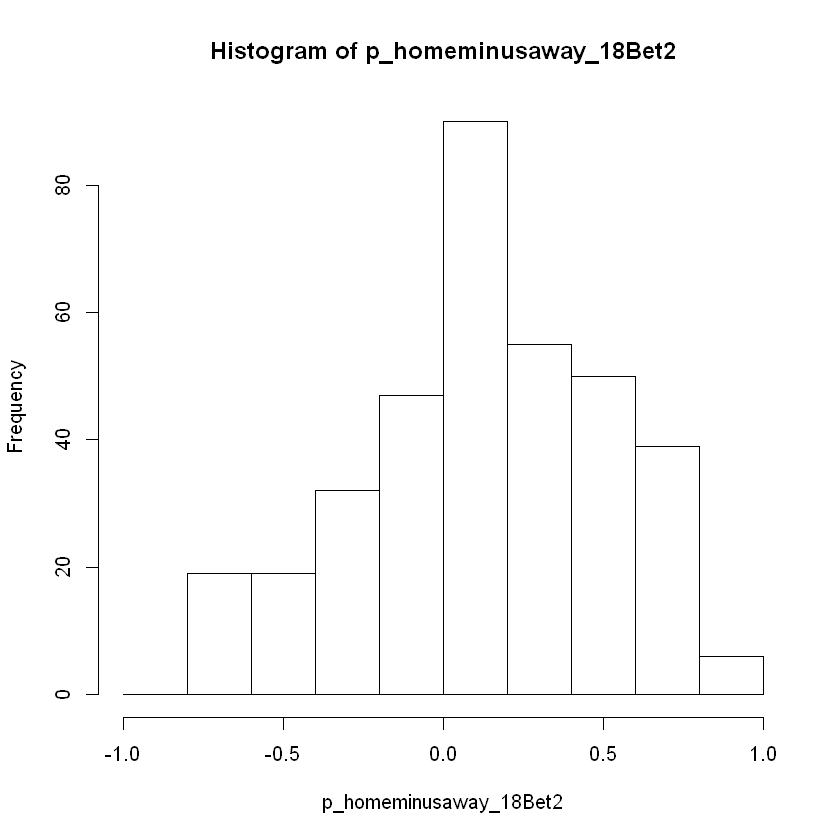

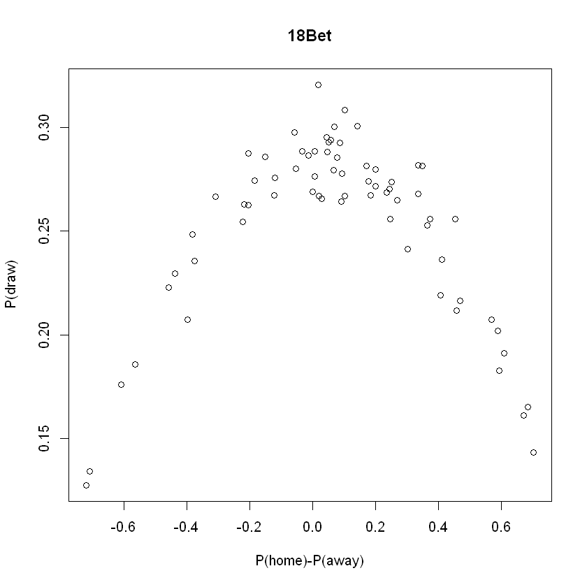

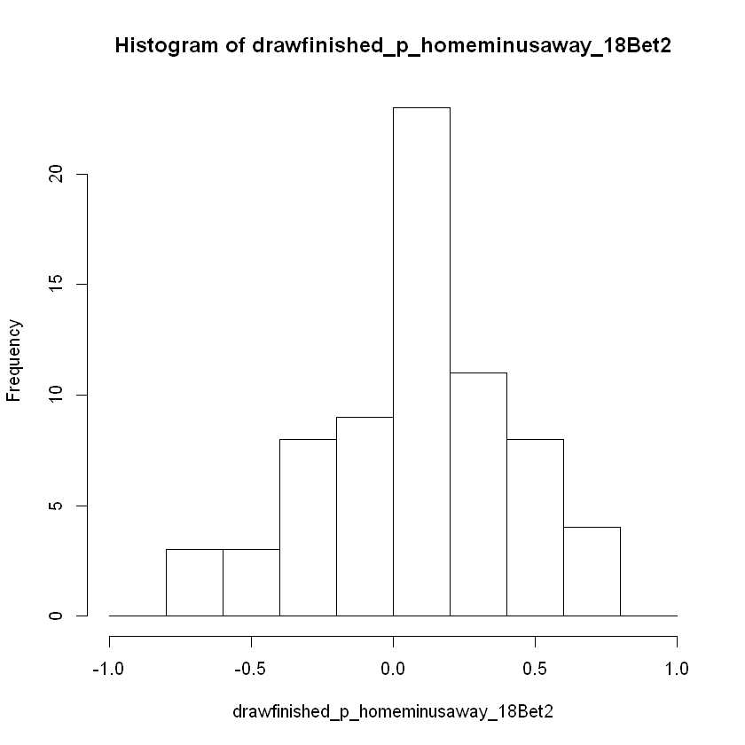

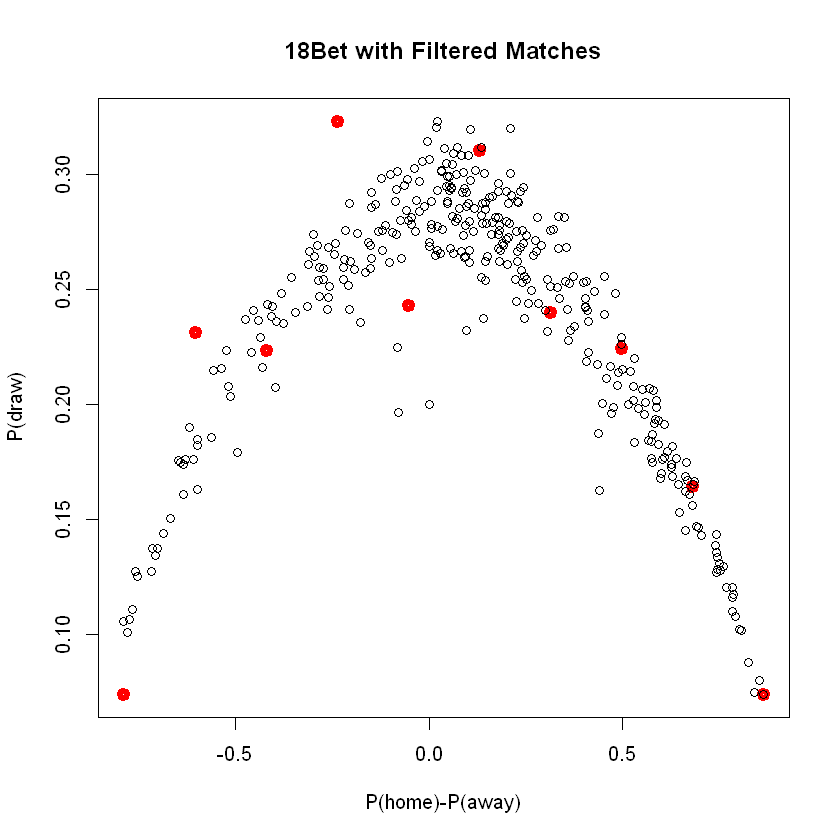

```r
bookmaker_18Bet2 <- alloddsnew[alloddsnew$odd_bookmakers=="18bet"]
bookmaker_18Bet2$oneovervalue <- 1 / bookmaker_18Bet2$value
sum_bookmaker_18Bet2 <- data.table(rowsum(bookmaker_18Bet2$oneovervalue,bookmaker_18Bet2$odd_epoch ), keep.rownames= TRUE)
names(sum_bookmaker_18Bet2) <- c("odd_epoch","odds_sum")
sum_bookmaker_18Bet2$odd_epoch <- as.numeric(as.character(sum_bookmaker_18Bet2$odd_epoch))
pre_oddsum_bookmaker_18Bet2 <- merge(bookmaker_18Bet2 , sum_bookmaker_18Bet2 , by = "odd_epoch")
oddsum_bookmaker_18Bet2 <- merge(pre_oddsum_bookmaker_18Bet2 , matches_after_extremegoals_and_red_cards , by = "match_id")
oddsum_bookmaker_18Bet2$odds_prob <- oddsum_bookmaker_18Bet2$oneovervalue / oddsum_bookmaker_18Bet2$odds_sum
draw_odd_bookmaker_18Bet2 <- oddsum_bookmaker_18Bet2[oddsum_bookmaker_18Bet2$variable=="odd_x"]
home_odd_bookmaker_18Bet2 <- oddsum_bookmaker_18Bet2[oddsum_bookmaker_18Bet2$variable=="odd_1"]
away_odd_bookmaker_18Bet2 <- oddsum_bookmaker_18Bet2[oddsum_bookmaker_18Bet2$variable=="odd_2"]
p_homeminusaway_18Bet2 <- home_odd_bookmaker_18Bet2$odds_prob - away_odd_bookmaker_18Bet2$odds_prob
plot(p_homeminusaway_18Bet2, draw_odd_bookmaker_18Bet2$odds_prob, main="18Bet", xlab="P(home)-P(away)", ylab="P(draw)")
allhist_18Bet2 <- hist(p_homeminusaway_18Bet2, breaks=c(-1,-0.8,-0.6,-0.4,-0.2,0,0.2,0.4,0.6,0.8,1))
drawfinished_18Bet2<- oddsum_bookmaker_18Bet2[oddsum_bookmaker_18Bet2$match_hometeam_score.y==oddsum_bookmaker_18Bet2$match_awayteam_score.y]
drawfinished_draw_odd_bookmaker_18Bet2 <- drawfinished_18Bet2[drawfinished_18Bet2$variable=="odd_x"]
drawfinished_home_odd_bookmaker_18Bet2 <- drawfinished_18Bet2[drawfinished_18Bet2$variable=="odd_1"]
drawfinished_away_odd_bookmaker_18Bet2 <- drawfinished_18Bet2[drawfinished_18Bet2$variable=="odd_2"]
drawfinished_p_homeminusaway_18Bet2 <- drawfinished_home_odd_bookmaker_18Bet2$odds_prob - drawfinished_away_odd_bookmaker_18Bet2$odds_prob
plot(drawfinished_p_homeminusaway_18Bet2, drawfinished_draw_odd_bookmaker_18Bet2$odds_prob, main="18Bet", xlab="P(home)-P(away)", ylab="P(draw)")
histdrawfinished_18Bet2 <- hist(drawfinished_p_homeminusaway_18Bet2, breaks=c(-1,-0.8,-0.6,-0.4,-0.2,0,0.2,0.4,0.6,0.8,1))
plot(histdrawfinished_18Bet2$counts/allhist_Bwin$counts, col = "red", lwd=5, xlab="", ylab="", axes=FALSE)
par(new=TRUE)
plot(p_homeminusaway_18Bet2, draw_odd_bookmaker_18Bet2$odds_prob, main="18Bet with Filtered Matches", xlab="P(home)-P(away)", ylab="P(draw)")
```

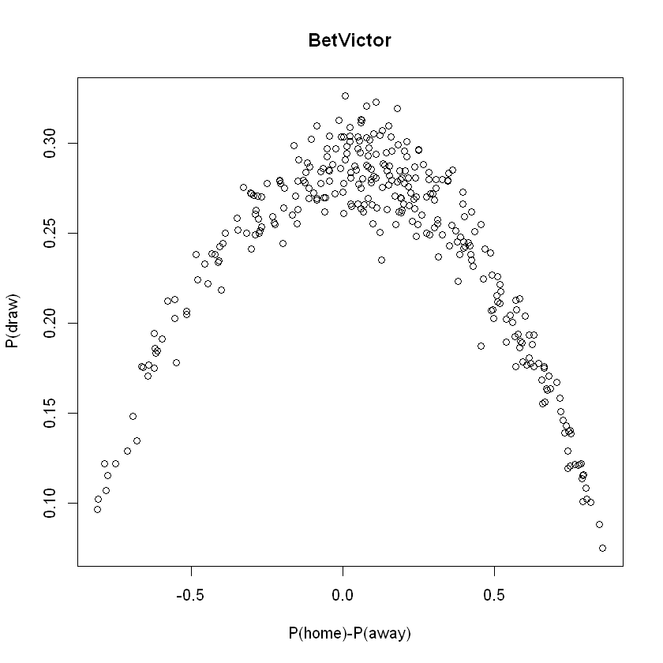

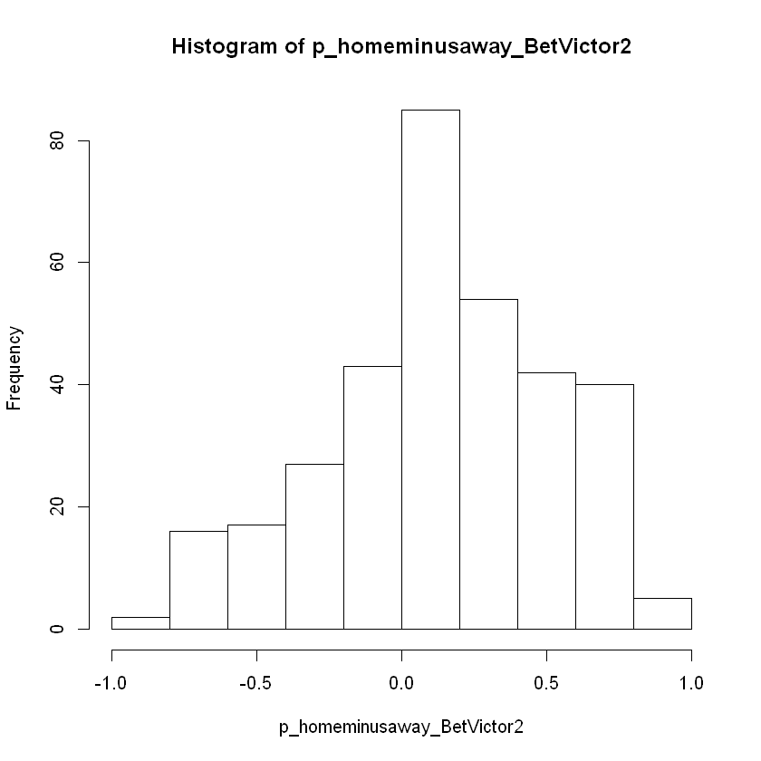

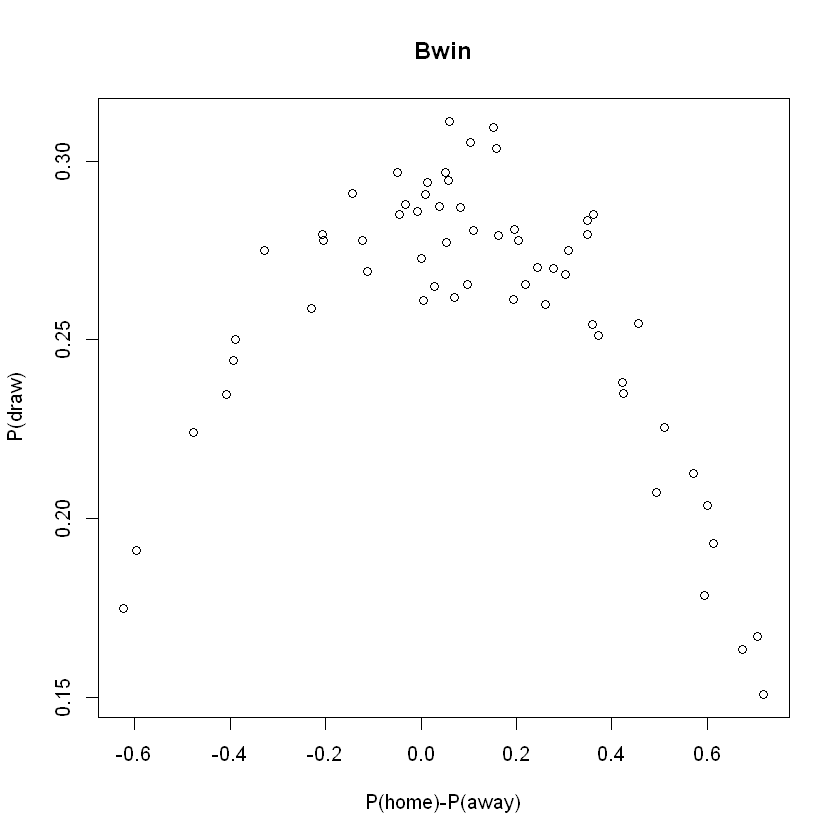

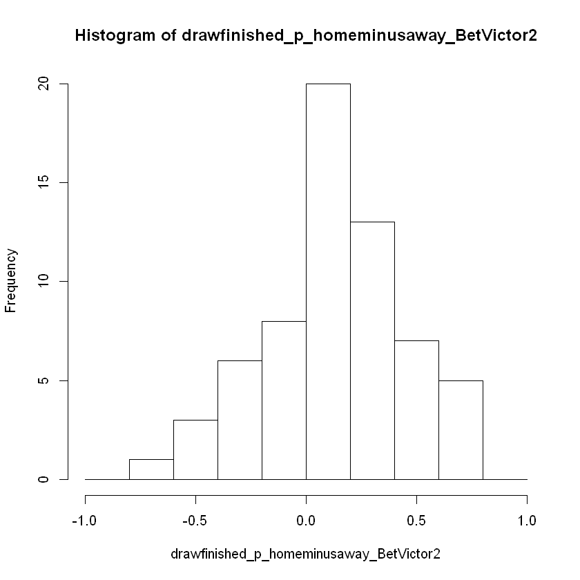

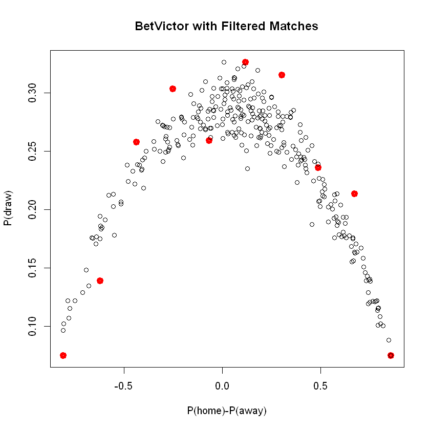

```r
bookmaker_BetVictor2 <- alloddsnew[alloddsnew$odd_bookmakers=="BetVictor"]
bookmaker_BetVictor2$oneovervalue <- 1 / bookmaker_BetVictor2$value
sum_bookmaker_BetVictor2 <- data.table(rowsum(bookmaker_BetVictor2$oneovervalue,bookmaker_BetVictor2$odd_epoch ), keep.rownames= TRUE)
names(sum_bookmaker_BetVictor2) <- c("odd_epoch","odds_sum")
sum_bookmaker_BetVictor2$odd_epoch <- as.numeric(as.character(sum_bookmaker_BetVictor2$odd_epoch))
pre_oddsum_bookmaker_BetVictor2 <- merge(bookmaker_BetVictor2 , sum_bookmaker_BetVictor2 , by = "odd_epoch")
oddsum_bookmaker_BetVictor2 <- merge(pre_oddsum_bookmaker_BetVictor2 , matches_after_extremegoals_and_red_cards , by = "match_id")
oddsum_bookmaker_BetVictor2$odds_prob <- oddsum_bookmaker_BetVictor2$oneovervalue / oddsum_bookmaker_BetVictor2$odds_sum
draw_odd_bookmaker_BetVictor2 <- oddsum_bookmaker_BetVictor2[oddsum_bookmaker_BetVictor2$variable=="odd_x"]
home_odd_bookmaker_BetVictor2 <- oddsum_bookmaker_BetVictor2[oddsum_bookmaker_BetVictor2$variable=="odd_1"]
away_odd_bookmaker_BetVictor2 <- oddsum_bookmaker_BetVictor2[oddsum_bookmaker_BetVictor2$variable=="odd_2"]
p_homeminusaway_BetVictor2 <- home_odd_bookmaker_BetVictor2$odds_prob - away_odd_bookmaker_BetVictor2$odds_prob
plot(p_homeminusaway_BetVictor2, draw_odd_bookmaker_BetVictor2$odds_prob, main="BetVictor", xlab="P(home)-P(away)", ylab="P(draw)")
allhist_BetVictor2 <- hist(p_homeminusaway_BetVictor2, breaks=c(-1,-0.8,-0.6,-0.4,-0.2,0,0.2,0.4,0.6,0.8,1))
drawfinished_BetVictor2<- oddsum_bookmaker_BetVictor2[oddsum_bookmaker_BetVictor2$match_hometeam_score.y==oddsum_bookmaker_BetVictor2$match_awayteam_score.y]
drawfinished_draw_odd_bookmaker_BetVictor2 <- drawfinished_BetVictor2[drawfinished_BetVictor2$variable=="odd_x"]
drawfinished_home_odd_bookmaker_BetVictor2 <- drawfinished_BetVictor2[drawfinished_BetVictor2$variable=="odd_1"]
drawfinished_away_odd_bookmaker_BetVictor2 <- drawfinished_BetVictor2[drawfinished_BetVictor2$variable=="odd_2"]
drawfinished_p_homeminusaway_BetVictor2 <- drawfinished_home_odd_bookmaker_BetVictor2$odds_prob - drawfinished_away_odd_bookmaker_BetVictor2$odds_prob
plot(drawfinished_p_homeminusaway_BetVictor2, drawfinished_draw_odd_bookmaker_BetVictor2$odds_prob, main="Bwin", xlab="P(home)-P(away)", ylab="P(draw)")
histdrawfinished_BetVictor2 <- hist(drawfinished_p_homeminusaway_BetVictor2, breaks=c(-1,-0.8,-0.6,-0.4,-0.2,0,0.2,0.4,0.6,0.8,1))
plot(histdrawfinished_BetVictor2$counts/allhist_Bwin$counts, col = "red", lwd=5, xlab="", ylab="", axes=FALSE)
par(new=TRUE)
plot(p_homeminusaway_BetVictor2, draw_odd_bookmaker_BetVictor2$odds_prob, main="BetVictor with Filtered Matches", xlab="P(home)-P(away)", ylab="P(draw)")
```

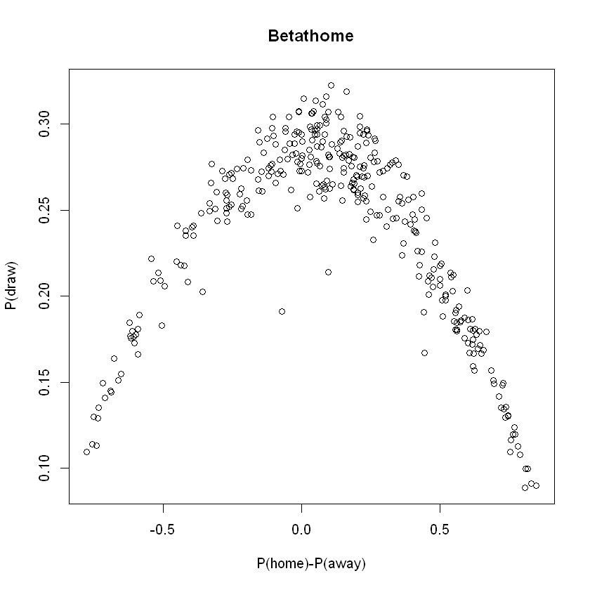

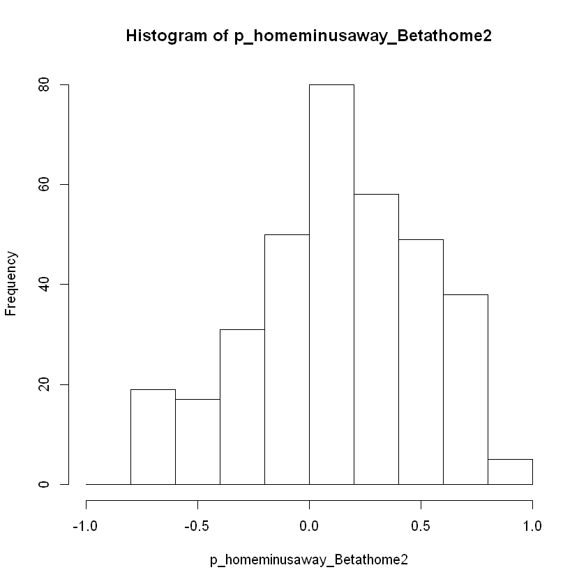

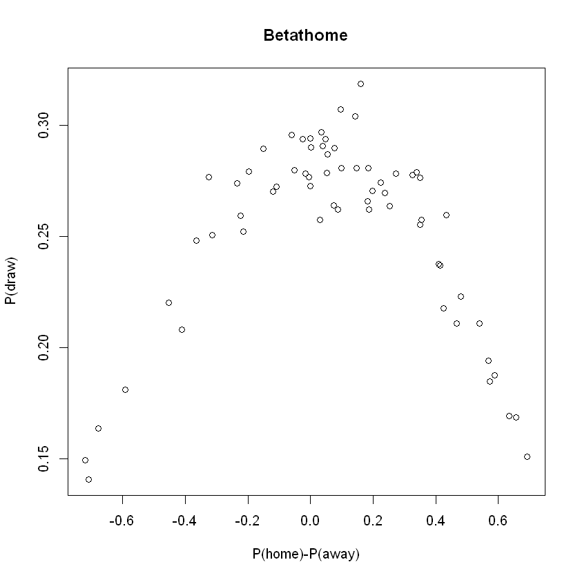

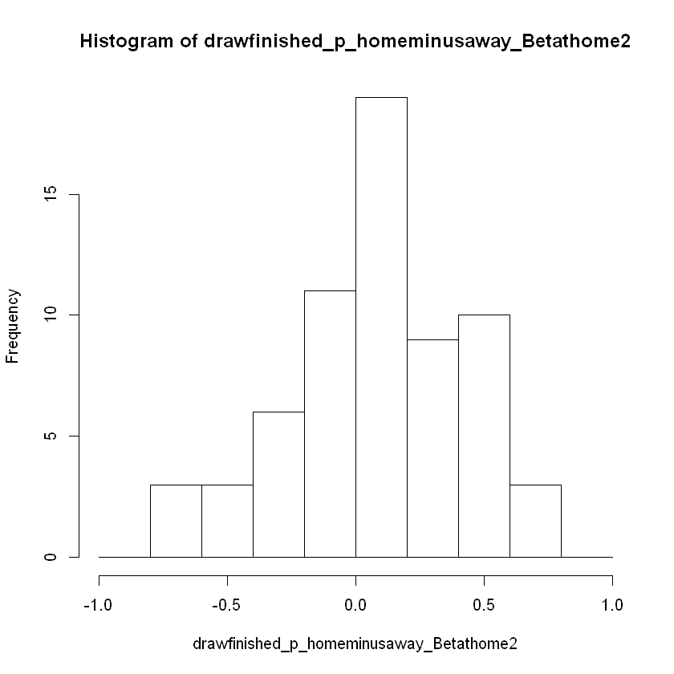

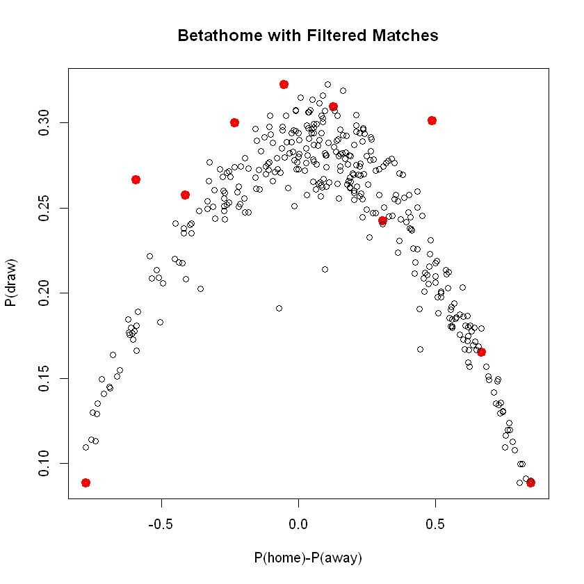

```r
bookmaker_Betathome2 <- alloddsnew[alloddsnew$odd_bookmakers=="bet-at-home"]
bookmaker_Betathome2$oneovervalue <- 1 / bookmaker_Betathome2$value
sum_bookmaker_Betathome2 <- data.table(rowsum(bookmaker_Betathome2$oneovervalue,bookmaker_Betathome2$odd_epoch ), keep.rownames= TRUE)
names(sum_bookmaker_Betathome2) <- c("odd_epoch","odds_sum")
sum_bookmaker_Betathome2$odd_epoch <- as.numeric(as.character(sum_bookmaker_Betathome2$odd_epoch))
pre_oddsum_bookmaker_Betathome2 <- merge(bookmaker_Betathome2 , sum_bookmaker_Betathome2 , by = "odd_epoch")
oddsum_bookmaker_Betathome2 <- merge(pre_oddsum_bookmaker_Betathome2 , matches_after_extremegoals_and_red_cards , by = "match_id")
oddsum_bookmaker_Betathome2$odds_prob <- oddsum_bookmaker_Betathome2$oneovervalue / oddsum_bookmaker_Betathome2$odds_sum
draw_odd_bookmaker_Betathome2 <- oddsum_bookmaker_Betathome2[oddsum_bookmaker_Betathome2$variable=="odd_x"]
home_odd_bookmaker_Betathome2 <- oddsum_bookmaker_Betathome2[oddsum_bookmaker_Betathome2$variable=="odd_1"]
away_odd_bookmaker_Betathome2 <- oddsum_bookmaker_Betathome2[oddsum_bookmaker_Betathome2$variable=="odd_2"]
p_homeminusaway_Betathome2 <- home_odd_bookmaker_Betathome2$odds_prob - away_odd_bookmaker_Betathome2$odds_prob
plot(p_homeminusaway_Betathome2, draw_odd_bookmaker_Betathome2$odds_prob, main="Betathome", xlab="P(home)-P(away)", ylab="P(draw)")
allhist_Betathome2 <- hist(p_homeminusaway_Betathome2, breaks=c(-1,-0.8,-0.6,-0.4,-0.2,0,0.2,0.4,0.6,0.8,1))
drawfinished_Betathome2<- oddsum_bookmaker_Betathome2[oddsum_bookmaker_Betathome2$match_hometeam_score.y==oddsum_bookmaker_Betathome2$match_awayteam_score.y]
drawfinished_draw_odd_bookmaker_Betathome2 <- drawfinished_Betathome2[drawfinished_Betathome2$variable=="odd_x"]
drawfinished_home_odd_bookmaker_Betathome2 <- drawfinished_Betathome2[drawfinished_Betathome2$variable=="odd_1"]
drawfinished_away_odd_bookmaker_Betathome2 <- drawfinished_Betathome2[drawfinished_Betathome2$variable=="odd_2"]
drawfinished_p_homeminusaway_Betathome2 <- drawfinished_home_odd_bookmaker_Betathome2$odds_prob - drawfinished_away_odd_bookmaker_Betathome2$odds_prob
plot(drawfinished_p_homeminusaway_Betathome2, drawfinished_draw_odd_bookmaker_Betathome2$odds_prob, main="Betathome", xlab="P(home)-P(away)", ylab="P(draw)")
histdrawfinished_Betathome2 <- hist(drawfinished_p_homeminusaway_Betathome2, breaks=c(-1,-0.8,-0.6,-0.4,-0.2,0,0.2,0.4,0.6,0.8,1))
plot(histdrawfinished_Betathome2$counts/allhist_Bwin$counts, col = "red", lwd=5, xlab="", ylab="", axes=FALSE)
par(new=TRUE)
plot(p_homeminusaway_Betathome2, draw_odd_bookmaker_Betathome2$odds_prob, main="Betathome with Filtered Matches", xlab="P(home)-P(away)", ylab="P(draw)")
```

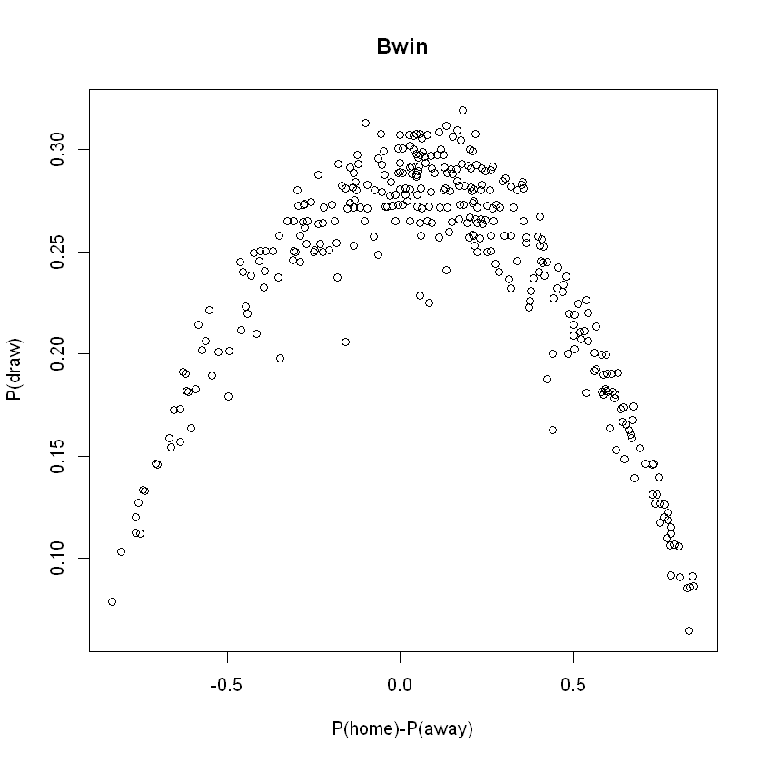

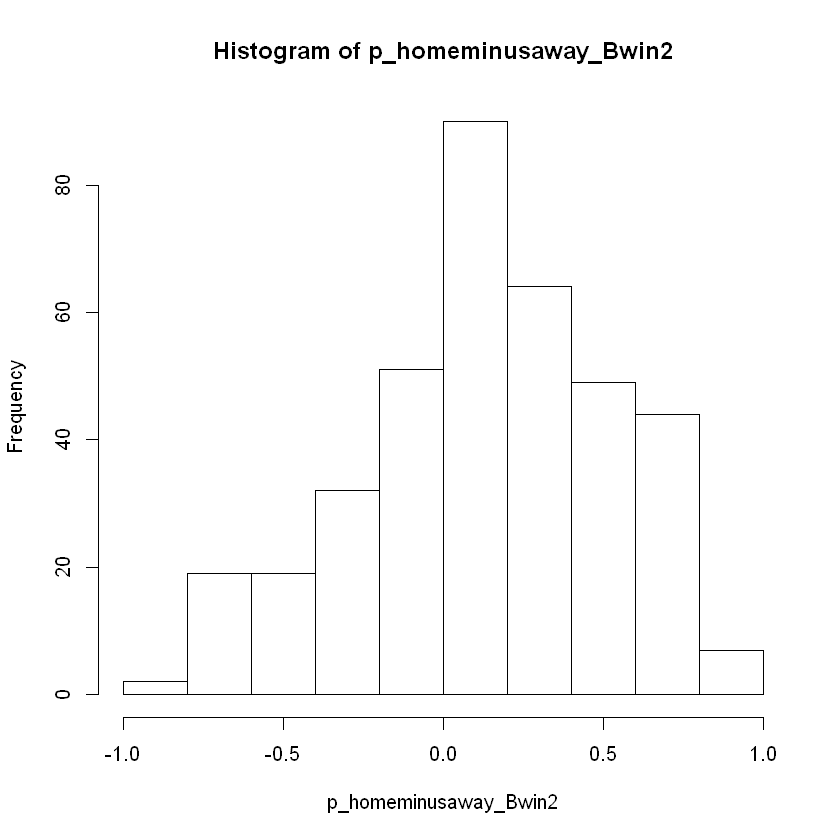

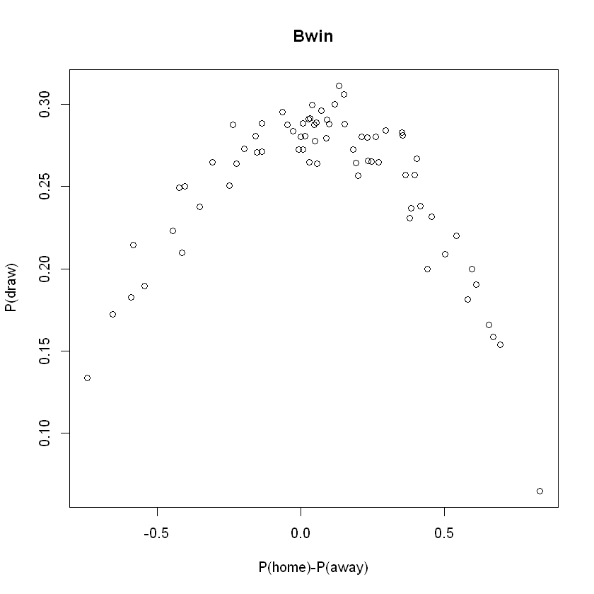

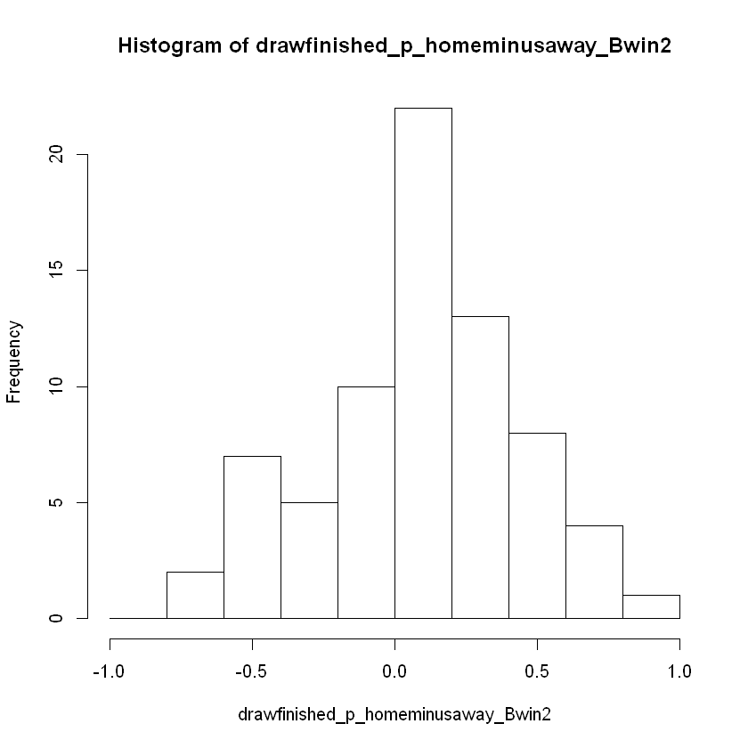

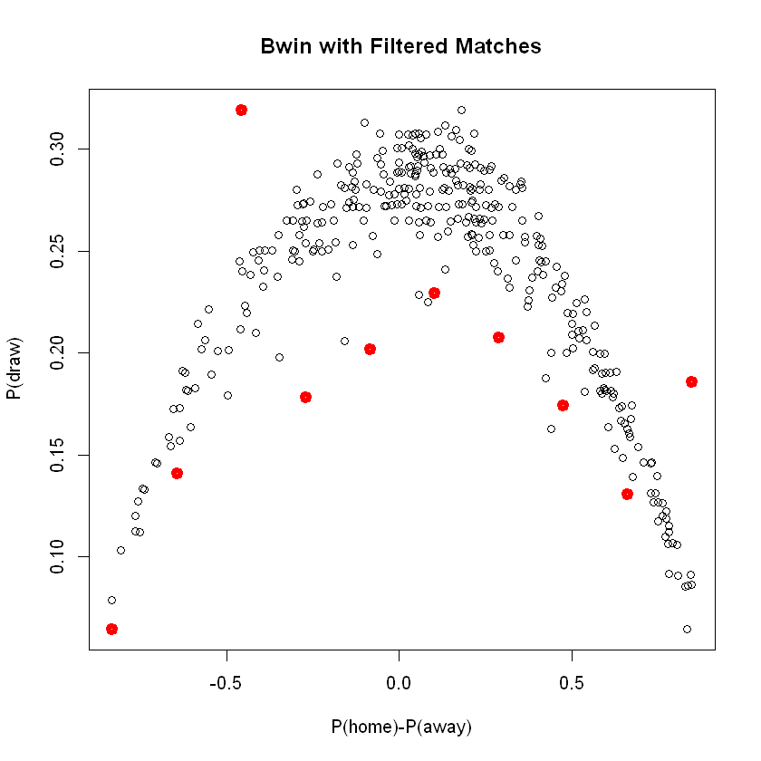

```r
bookmaker_Bwin2 <- alloddsnew[alloddsnew$odd_bookmakers=="bwin"]
bookmaker_Bwin2$oneovervalue <- 1 / bookmaker_Bwin2$value
sum_bookmaker_Bwin2 <- data.table(rowsum(bookmaker_Bwin2$oneovervalue,bookmaker_Bwin2$odd_epoch ), keep.rownames= TRUE)
names(sum_bookmaker_Bwin2) <- c("odd_epoch","odds_sum")
sum_bookmaker_Bwin2$odd_epoch <- as.numeric(as.character(sum_bookmaker_Bwin2$odd_epoch))
pre_oddsum_bookmaker_Bwin2 <- merge(bookmaker_Bwin2 , sum_bookmaker_Bwin2 , by = "odd_epoch")
oddsum_bookmaker_Bwin2 <- merge(pre_oddsum_bookmaker_Bwin2 , matches_after_extremegoals_and_red_cards , by = "match_id")
oddsum_bookmaker_Bwin2$odds_prob <- oddsum_bookmaker_Bwin2$oneovervalue / oddsum_bookmaker_Bwin2$odds_sum
draw_odd_bookmaker_Bwin2 <- oddsum_bookmaker_Bwin2[oddsum_bookmaker_Bwin2$variable=="odd_x"]
home_odd_bookmaker_Bwin2 <- oddsum_bookmaker_Bwin2[oddsum_bookmaker_Bwin2$variable=="odd_1"]
away_odd_bookmaker_Bwin2 <- oddsum_bookmaker_Bwin2[oddsum_bookmaker_Bwin2$variable=="odd_2"]
p_homeminusaway_Bwin2 <- home_odd_bookmaker_Bwin2$odds_prob - away_odd_bookmaker_Bwin2$odds_prob
plot(p_homeminusaway_Bwin2, draw_odd_bookmaker_Bwin2$odds_prob, main="Bwin", xlab="P(home)-P(away)", ylab="P(draw)")
allhist_Bwin2 <- hist(p_homeminusaway_Bwin2, breaks=c(-1,-0.8,-0.6,-0.4,-0.2,0,0.2,0.4,0.6,0.8,1))
drawfinished_Bwin2<- oddsum_bookmaker_Bwin2[oddsum_bookmaker_Bwin2$match_hometeam_score.y==oddsum_bookmaker_Bwin2$match_awayteam_score.y]
drawfinished_draw_odd_bookmaker_Bwin2 <- drawfinished_Bwin2[drawfinished_Bwin2$variable=="odd_x"]
drawfinished_home_odd_bookmaker_Bwin2 <- drawfinished_Bwin2[drawfinished_Bwin2$variable=="odd_1"]
drawfinished_away_odd_bookmaker_Bwin2 <- drawfinished_Bwin2[drawfinished_Bwin2$variable=="odd_2"]
drawfinished_p_homeminusaway_Bwin2 <- drawfinished_home_odd_bookmaker_Bwin2$odds_prob - drawfinished_away_odd_bookmaker_Bwin2$odds_prob
plot(drawfinished_p_homeminusaway_Bwin2, drawfinished_draw_odd_bookmaker_Bwin2$odds_prob, main="Bwin", xlab="P(home)-P(away)", ylab="P(draw)")
histdrawfinished_Bwin2 <- hist(drawfinished_p_homeminusaway_Bwin2, breaks=c(-1,-0.8,-0.6,-0.4,-0.2,0,0.2,0.4,0.6,0.8,1))
plot(histdrawfinished_Bwin2$counts/allhist_Bwin$counts, col = "red", lwd=5, xlab="", ylab="", axes=FALSE)
par(new=TRUE)
plot(p_homeminusaway_Bwin2, draw_odd_bookmaker_Bwin2$odds_prob, main="Bwin with Filtered Matches", xlab="P(home)-P(away)", ylab="P(draw)")
```